# Gather

### 1. The WeRateDog twitter archive from Udacity csv file

```python
import pandas as pd
import numpy as np
```

```python
twitter_archives = pd.read_csv('twitter-archive-enhanced.csv')
twitter_archives.head(2)
```

|  | tweet_id | in_reply_to_status_id | in_reply_to_user_id | timestamp | source | text | retweeted_status_id | retweeted_status_user_id | retweeted_status_timestamp | expanded_urls | rating_numerator | rating_denominator | name | doggo | floofer | pupper | puppo |
| --- | --- | --- | --- | --- | --- | --- | --- | --- | --- | --- | --- | --- | --- | --- | --- | --- | --- |
| 0 | 892420643555336193 | NaN | NaN | 2017-08-01 16:23:56 +0000 | <a href="http://twitter.com/download/iphone" r... | This is Phineas. He's a mystical boy. Only eve... | NaN | NaN | NaN | https://twitter.com/dog_rates/status/892420643... | 13 | 10 | Phineas | None | None | None | None |
| 1 | 892177421306343426 | NaN | NaN | 2017-08-01 00:17:27 +0000 | <a href="http://twitter.com/download/iphone" r... | This is Tilly. She's just checking pup on you.... | NaN | NaN | NaN | https://twitter.com/dog_rates/status/892177421... | 13 | 10 | Tilly | None | None | None | None |

### 2. Image Prediction of Tweet

```python
import requests
from io import BytesIO
```

```python
data = requests.get(' https://d17h27t6h515a5.cloudfront.net/topher/2017/August/599fd2ad_image-predictions/image-predictions.tsv')
```

```python
image_predictions = pd.read_csv(BytesIO(data.content),sep='\t')
image_predictions.to_csv('image_predictions.tsv')
```

### 3. Retweet count and favorite count data from twitter api

```python
import json
import tweepy
```

```python
consumer_key = ''
consumer_secret = ''
access_token = ''
access_secret = ''
```

```python
auth = tweepy.OAuthHandler(consumer_key, consumer_secret)
auth.set_access_token(access_token, access_secret)

api = tweepy.API(auth, wait_on_rate_limit=True, wait_on_rate_limit_notify=True)
```

```python
with open("tweet_json.txt", "w") as outfile:
    for tweet_id in twitter_archives['tweet_id']:
        try:
            tweet = api.get_status(tweet_id, tweet_mode = 'extended')
            json.dump(tweet._json, outfile)
            outfile.write("\n")
        except Exception as e:
            print(str(tweet_id) + str(e))
```

[output not shown]

```
Rate limit reached. Sleeping for: 412
```

```
754011816964026368[{'code': 144, 'message': 'No status found with that ID.'}]
680055455951884288[{'code': 144, 'message': 'No status found with that ID.'}]
```

```
Rate limit reached. Sleeping for: 442
```

```python
data = []
with open('tweet_json.txt', 'r') as readfile:
    tweet_json = readfile.readline()
    while tweet_json:
        tweet_dict = json.loads(tweet_json)
        data.append(tweet_dict)
        tweet_json = readfile.readline()

tweet_api_data = pd.DataFrame.from_dict(data)
```

# Assess

```python
tweet_api_data
```

|  | contributors | coordinates | created_at | display_text_range | entities | extended_entities | favorite_count | favorited | full_text | geo | ... | quoted_status | quoted_status_id | quoted_status_id_str | quoted_status_permalink | retweet_count | retweeted | retweeted_status | source | truncated | user |
| --- | --- | --- | --- | --- | --- | --- | --- | --- | --- | --- | --- | --- | --- | --- | --- | --- | --- | --- | --- | --- | --- |
| 0 | None | None | Tue Aug 01 16:23:56 +0000 2017 | [0, 85] | {'hashtags': [], 'symbols': [], 'user_mentions... | {'media': [{'id': 892420639486877696, 'id_str'... | 37084 | False | This is Phineas. He's a mystical boy. Only eve... | None | ... | NaN | NaN | NaN | NaN | 7923 | False | NaN | <a href="http://twitter.com/download/iphone" r... | False | {'id': 4196983835, 'id_str': '4196983835', 'na... |
| 1 | None | None | Tue Aug 01 00:17:27 +0000 2017 | [0, 138] | {'hashtags': [], 'symbols': [], 'user_mentions... | {'media': [{'id': 892177413194625024, 'id_str'... | 31911 | False | This is Tilly. She's just checking pup on you.... | None | ... | NaN | NaN | NaN | NaN | 5886 | False | NaN | <a href="http://twitter.com/download/iphone" r... | False | {'id': 4196983835, 'id_str': '4196983835', 'na... |
| 2 | None | None | Mon Jul 31 00:18:03 +0000 2017 | [0, 121] | {'hashtags': [], 'symbols': [], 'user_mentions... | {'media': [{'id': 891815175371796480, 'id_str'... | 24026 | False | This is Archie. He is a rare Norwegian Pouncin... | None | ... | NaN | NaN | NaN | NaN | 3886 | False | NaN | <a href="http://twitter.com/download/iphone" r... | False | {'id': 4196983835, 'id_str': '4196983835', 'na... |
| 3 | None | None | Sun Jul 30 15:58:51 +0000 2017 | [0, 79] | {'hashtags': [], 'symbols': [], 'user_mentions... | {'media': [{'id': 891689552724799489, 'id_str'... | 40406 | False | This is Darla. She commenced a snooze mid meal... | None | ... | NaN | NaN | NaN | NaN | 8069 | False | NaN | <a href="http://twitter.com/download/iphone" r... | False | {'id': 4196983835, 'id_str': '4196983835', 'na... |
| 4 | None | None | Sat Jul 29 16:00:24 +0000 2017 | [0, 138] | {'hashtags': [{'text': 'BarkWeek', 'indices': ... | {'media': [{'id': 891327551943041024, 'id_str'... | 38629 | False | This is Franklin. He would like you to stop ca... | None | ... | NaN | NaN | NaN | NaN | 8756 | False | NaN | <a href="http://twitter.com/download/iphone" r... | False | {'id': 4196983835, 'id_str': '4196983835', 'na... |
| 5 | None | None | Sat Jul 29 00:08:17 +0000 2017 | [0, 138] | {'hashtags': [{'text': 'BarkWeek', 'indices': ... | {'media': [{'id': 891087942176911360, 'id_str'... | 19410 | False | Here we have a majestic great white breaching ... | None | ... | NaN | NaN | NaN | NaN | 2908 | False | NaN | <a href="http://twitter.com/download/iphone" r... | False | {'id': 4196983835, 'id_str': '4196983835', 'na... |
| 6 | None | None | Fri Jul 28 16:27:12 +0000 2017 | [0, 140] | {'hashtags': [], 'symbols': [], 'user_mentions... | {'media': [{'id': 890971906207338496, 'id_str'... | 11325 | False | Meet Jax. He enjoys ice cream so much he gets ... | None | ... | NaN | NaN | NaN | NaN | 1930 | False | NaN | <a href="http://twitter.com/download/iphone" r... | False | {'id': 4196983835, 'id_str': '4196983835', 'na... |
| 7 | None | None | Fri Jul 28 00:22:40 +0000 2017 | [0, 118] | {'hashtags': [], 'symbols': [], 'user_mentions... | {'media': [{'id': 890729118844600320, 'id_str'... | 62555 | False | When you watch your owner call another dog a g... | None | ... | NaN | NaN | NaN | NaN | 17669 | False | NaN | <a href="http://twitter.com/download/iphone" r... | False | {'id': 4196983835, 'id_str': '4196983835', 'na... |
| 8 | None | None | Thu Jul 27 16:25:51 +0000 2017 | [0, 122] | {'hashtags': [{'text': 'BarkWeek', 'indices': ... | {'media': [{'id': 890609177319665665, 'id_str'... | 26717 | False | This is Zoey. She doesn't want to be one of th... | None | ... | NaN | NaN | NaN | NaN | 4011 | False | NaN | <a href="http://twitter.com/download/iphone" r... | False | {'id': 4196983835, 'id_str': '4196983835', 'na... |
| 9 | None | None | Wed Jul 26 15:59:51 +0000 2017 | [0, 133] | {'hashtags': [], 'symbols': [], 'user_mentions... | {'media': [{'id': 890240245463175168, 'id_str'... | 30588 | False | This is Cassie. She is a college pup. Studying... | None | ... | NaN | NaN | NaN | NaN | 6893 | False | NaN | <a href="http://twitter.com/download/iphone" r... | False | {'id': 4196983835, 'id_str': '4196983835', 'na... |
| 10 | None | None | Wed Jul 26 00:31:25 +0000 2017 | [0, 130] | {'hashtags': [{'text': 'BarkWeek', 'indices': ... | {'media': [{'id': 890006600089468928, 'id_str'... | 29448 | False | This is Koda. He is a South Australian decksha... | None | ... | NaN | NaN | NaN | NaN | 6864 | False | NaN | <a href="http://twitter.com/download/iphone" r... | False | {'id': 4196983835, 'id_str': '4196983835', 'na... |
| 11 | None | None | Tue Jul 25 16:11:53 +0000 2017 | [0, 107] | {'hashtags': [], 'symbols': [], 'user_mentions... | {'media': [{'id': 889880888800096258, 'id_str'... | 26720 | False | This is Bruno. He is a service shark. Only get... | None | ... | NaN | NaN | NaN | NaN | 4672 | False | NaN | <a href="http://twitter.com/download/iphone" r... | False | {'id': 4196983835, 'id_str': '4196983835', 'na... |
| 12 | None | None | Tue Jul 25 01:55:32 +0000 2017 | [0, 106] | {'hashtags': [], 'symbols': [], 'user_mentions... | {'media': [{'id': 889665366129029120, 'id_str'... | 46092 | False | Here's a puppo that seems to be on the fence a... | None | ... | NaN | NaN | NaN | NaN | 9398 | False | NaN | <a href="http://twitter.com/download/iphone" r... | False | {'id': 4196983835, 'id_str': '4196983835', 'na... |
| 13 | None | None | Tue Jul 25 00:10:02 +0000 2017 | [0, 91] | {'hashtags': [], 'symbols': [], 'user_mentions... | {'media': [{'id': 889638825424826374, 'id_str'... | 25979 | False | This is Ted. He does his best. Sometimes that'... | None | ... | NaN | NaN | NaN | NaN | 4219 | False | NaN | <a href="http://twitter.com/download/iphone" r... | False | {'id': 4196983835, 'id_str': '4196983835', 'na... |
| 14 | None | None | Mon Jul 24 17:02:04 +0000 2017 | [0, 118] | {'hashtags': [{'text': 'BarkWeek', 'indices': ... | {'media': [{'id': 889531127467266049, 'id_str'... | 14504 | False | This is Stuart. He's sporting his favorite fan... | None | ... | NaN | NaN | NaN | NaN | 2113 | False | NaN | <a href="http://twitter.com/download/iphone" r... | False | {'id': 4196983835, 'id_str': '4196983835', 'na... |
| 15 | None | None | Mon Jul 24 00:19:32 +0000 2017 | [0, 138] | {'hashtags': [{'text': 'BarkWeek', 'indices': ... | {'media': [{'id': 889278779352338437, 'id_str'... | 24189 | False | This is Oliver. You're witnessing one of his m... | None | ... | NaN | NaN | NaN | NaN | 5018 | False | NaN | <a href="http://twitter.com/download/iphone" r... | False | {'id': 4196983835, 'id_str': '4196983835', 'na... |
| 16 | None | None | Sun Jul 23 00:22:39 +0000 2017 | [0, 86] | {'hashtags': [], 'symbols': [], 'user_mentions... | {'media': [{'id': 888917229776945152, 'id_str'... | 27922 | False | This is Jim. He found a fren. Taught him how t... | None | ... | NaN | NaN | NaN | NaN | 4208 | False | NaN | <a href="http://twitter.com/download/iphone" r... | False | {'id': 4196983835, 'id_str': '4196983835', 'na... |
| 17 | None | None | Sat Jul 22 16:56:37 +0000 2017 | [0, 128] | {'hashtags': [], 'symbols': [], 'user_mentions... | {'media': [{'id': 888804981515575296, 'id_str'... | 24522 | False | This is Zeke. He has a new stick. Very proud o... | None | ... | NaN | NaN | NaN | NaN | 3988 | False | NaN | <a href="http://twitter.com/download/iphone" r... | False | {'id': 4196983835, 'id_str': '4196983835', 'na... |
| 18 | None | None | Sat Jul 22 00:23:06 +0000 2017 | [0, 87] | {'hashtags': [], 'symbols': [], 'user_mentions... | {'media': [{'id': 888554915546542081, 'id_str'... | 18988 | False | This is Ralphus. He's powering up. Attempting ... | None | ... | NaN | NaN | NaN | NaN | 3288 | False | NaN | <a href="http://twitter.com/download/iphone" r... | False | {'id': 4196983835, 'id_str': '4196983835', 'na... |
| 19 | None | None | Thu Jul 20 16:49:33 +0000 2017 | [0, 127] | {'hashtags': [], 'symbols': [], 'user_mentions... | {'media': [{'id': 888078426338406400, 'id_str'... | 20862 | False | This is Gerald. He was just told he didn't get... | None | ... | NaN | NaN | NaN | NaN | 3258 | False | NaN | <a href="http://twitter.com/download/iphone" r... | False | {'id': 4196983835, 'id_str': '4196983835', 'na... |
| 20 | None | None | Wed Jul 19 16:06:48 +0000 2017 | [0, 127] | {'hashtags': [], 'symbols': [], 'user_mentions... | {'media': [{'id': 887705281597243393, 'id_str'... | 28981 | False | This is Jeffrey. He has a monopoly on the pool... | None | ... | NaN | NaN | NaN | NaN | 5044 | False | NaN | <a href="http://twitter.com/download/iphone" r... | False | {'id': 4196983835, 'id_str': '4196983835', 'na... |
| 21 | None | None | Wed Jul 19 03:39:09 +0000 2017 | [0, 108] | {'hashtags': [], 'symbols': [], 'user_mentions... | {'media': [{'id': 887517108413886465, 'id_str'... | 44441 | False | I've yet to rate a Venezuelan Hover Wiener. Th... | None | ... | NaN | NaN | NaN | NaN | 10990 | False | NaN | <a href="http://twitter.com/download/iphone" r... | False | {'id': 4196983835, 'id_str': '4196983835', 'na... |
| 22 | None | None | Wed Jul 19 00:47:34 +0000 2017 | [0, 99] | {'hashtags': [], 'symbols': [], 'user_mentions... | {'media': [{'id': 887473949361045505, 'id_str'... | 66063 | False | This is Canela. She attempted some fancy porch... | None | ... | NaN | NaN | NaN | NaN | 16893 | False | NaN | <a href="http://twitter.com/download/iphone" r... | False | {'id': 4196983835, 'id_str': '4196983835', 'na... |
| 23 | None | None | Tue Jul 18 16:08:03 +0000 2017 | [0, 88] | {'hashtags': [], 'symbols': [], 'user_mentions... | {'media': [{'id': 887343120832229379, 'id_str'... | 32294 | False | You may not have known you needed to see this ... | None | ... | NaN | NaN | NaN | NaN | 9796 | False | NaN | <a href="http://twitter.com/download/iphone" r... | False | {'id': 4196983835, 'id_str': '4196983835', 'na... |
| 24 | None | None | Tue Jul 18 00:07:08 +0000 2017 | [0, 129] | {'hashtags': [], 'symbols': [], 'user_mentions... | {'media': [{'id': 887101385971384320, 'id_str'... | 29325 | False | This... is a Jubilant Antarctic House Bear. We... | None | ... | NaN | NaN | NaN | NaN | 5578 | False | NaN | <a href="http://twitter.com/download/iphone" r... | False | {'id': 4196983835, 'id_str': '4196983835', 'na... |
| 25 | None | None | Mon Jul 17 16:17:36 +0000 2017 | [0, 101] | {'hashtags': [], 'symbols': [], 'user_mentions... | {'media': [{'id': 886983218871902208, 'id_str'... | 33625 | False | This is Maya. She's very shy. Rarely leaves he... | None | ... | NaN | NaN | NaN | NaN | 7189 | False | NaN | <a href="http://twitter.com/download/iphone" r... | False | {'id': 4196983835, 'id_str': '4196983835', 'na... |
| 26 | None | None | Sun Jul 16 23:58:41 +0000 2017 | [0, 121] | {'hashtags': [], 'symbols': [], 'user_mentions... | {'media': [{'id': 886736868116754432, 'id_str'... | 11525 | False | This is Mingus. He's a wonderful father to his... | None | ... | NaN | NaN | NaN | NaN | 3034 | False | NaN | <a href="http://twitter.com/download/iphone" r... | False | {'id': 4196983835, 'id_str': '4196983835', 'na... |
| 27 | None | None | Sun Jul 16 20:14:00 +0000 2017 | [0, 71] | {'hashtags': [], 'symbols': [], 'user_mentions... | {'media': [{'id': 886680331239161856, 'id_str'... | 21505 | False | This is Derek. He's late for a dog meeting. 13... | None | ... | NaN | NaN | NaN | NaN | 4175 | False | NaN | <a href="http://twitter.com/download/iphone" r... | False | {'id': 4196983835, 'id_str': '4196983835', 'na... |
| 28 | None | None | Sat Jul 15 23:25:31 +0000 2017 | [0, 131] | {'hashtags': [], 'symbols': [], 'user_mentions... | {'media': [{'id': 886366138128449536, 'id_str'... | 20288 | False | This is Roscoe. Another pupper fallen victim t... | None | ... | NaN | NaN | NaN | NaN | 2987 | False | NaN | <a href="http://twitter.com/download/iphone" r... | False | {'id': 4196983835, 'id_str': '4196983835', 'na... |
| 29 | None | None | Sat Jul 15 16:51:35 +0000 2017 | [27, 105] | {'hashtags': [], 'symbols': [], 'user_mentions... | NaN | 115 | False | @NonWhiteHat @MayhewMayhem omg hello tanner yo... | None | ... | NaN | NaN | NaN | NaN | 4 | False | NaN | <a href="http://twitter.com/download/iphone" r... | False | {'id': 4196983835, 'id_str': '4196983835', 'na... |
| ... | ... | ... | ... | ... | ... | ... | ... | ... | ... | ... | ... | ... | ... | ... | ... | ... | ... | ... | ... | ... | ... |
| 2302 | None | None | Tue Nov 17 00:24:19 +0000 2015 | [0, 140] | {'hashtags': [], 'symbols': [], 'user_mentions... | {'media': [{'id': 666411498068123649, 'id_str'... | 424 | False | This is quite the dog. Gets really excited whe... | None | ... | NaN | NaN | NaN | NaN | 314 | False | NaN | <a href="http://twitter.com/download/iphone" r... | False | {'id': 4196983835, 'id_str': '4196983835', 'na... |
| 2303 | None | None | Tue Nov 17 00:06:54 +0000 2015 | [0, 139] | {'hashtags': [], 'symbols': [], 'user_mentions... | {'media': [{'id': 666407121513275392, 'id_str'... | 101 | False | This is a southern Vesuvius bumblegruff. Can d... | None | ... | NaN | NaN | NaN | NaN | 35 | False | NaN | <a href="http://twitter.com/download/iphone" r... | False | {'id': 4196983835, 'id_str': '4196983835', 'na... |
| 2304 | None | None | Mon Nov 16 23:23:41 +0000 2015 | [0, 137] | {'hashtags': [], 'symbols': [], 'user_mentions... | {'media': [{'id': 666396240351993856, 'id_str'... | 160 | False | Oh goodness. A super rare northeast Qdoba kang... | None | ... | NaN | NaN | NaN | NaN | 80 | False | NaN | <a href="http://twitter.com/download/iphone" r... | False | {'id': 4196983835, 'id_str': '4196983835', 'na... |
| 2305 | None | None | Mon Nov 16 21:54:18 +0000 2015 | [0, 81] | {'hashtags': [], 'symbols': [], 'user_mentions... | {'media': [{'id': 666373746337402880, 'id_str'... | 177 | False | Those are sunglasses and a jean jacket. 11/10 ... | None | ... | NaN | NaN | NaN | NaN | 86 | False | NaN | <a href="http://twitter.com/download/iphone" r... | False | {'id': 4196983835, 'id_str': '4196983835', 'na... |
| 2306 | None | None | Mon Nov 16 21:10:36 +0000 2015 | [0, 140] | {'hashtags': [], 'symbols': [], 'user_mentions... | {'media': [{'id': 666362717482020864, 'id_str'... | 744 | False | Unique dog here. Very small. Lives in containe... | None | ... | NaN | NaN | NaN | NaN | 535 | False | NaN | <a href="http://twitter.com/download/iphone" r... | False | {'id': 4196983835, 'id_str': '4196983835', 'na... |
| 2307 | None | None | Mon Nov 16 20:32:58 +0000 2015 | [0, 135] | {'hashtags': [], 'symbols': [], 'user_mentions... | {'media': [{'id': 666353280906170368, 'id_str'... | 209 | False | Here we have a mixed Asiago from the Galápagos... | None | ... | NaN | NaN | NaN | NaN | 71 | False | NaN | <a href="http://twitter.com/download/iphone" r... | False | {'id': 4196983835, 'id_str': '4196983835', 'na... |
| 2308 | None | None | Mon Nov 16 20:01:42 +0000 2015 | [0, 112] | {'hashtags': [], 'symbols': [], 'user_mentions... | {'media': [{'id': 666345414279471104, 'id_str'... | 280 | False | Look at this jokester thinking seat belt laws ... | None | ... | NaN | NaN | NaN | NaN | 129 | False | NaN | <a href="http://twitter.com/download/iphone" r... | False | {'id': 4196983835, 'id_str': '4196983835', 'na... |
| 2309 | None | None | Mon Nov 16 19:31:45 +0000 2015 | [0, 139] | {'hashtags': [], 'symbols': [], 'user_mentions... | {'media': [{'id': 666337857791987715, 'id_str'... | 186 | False | This is an extremely rare horned Parthenon. No... | None | ... | NaN | NaN | NaN | NaN | 86 | False | NaN | <a href="http://twitter.com/download/iphone" r... | False | {'id': 4196983835, 'id_str': '4196983835', 'na... |
| 2310 | None | None | Mon Nov 16 16:37:02 +0000 2015 | [0, 138] | {'hashtags': [], 'symbols': [], 'user_mentions... | {'media': [{'id': 666293909010702337, 'id_str'... | 476 | False | This is a funny dog. Weird toes. Won't come do... | None | ... | NaN | NaN | NaN | NaN | 327 | False | NaN | <a href="http://twitter.com/download/iphone" r... | False | {'id': 4196983835, 'id_str': '4196983835', 'na... |
| 2311 | None | None | Mon Nov 16 16:11:11 +0000 2015 | [0, 136] | {'hashtags': [], 'symbols': [], 'user_mentions... | {'media': [{'id': 666287399580733440, 'id_str'... | 140 | False | This is an Albanian 3 1/2 legged Episcopalian... | None | ... | NaN | NaN | NaN | NaN | 63 | False | NaN | <a href="http://twitter.com/download/iphone" r... | False | {'id': 4196983835, 'id_str': '4196983835', 'na... |
| 2312 | None | None | Mon Nov 16 15:14:19 +0000 2015 | [0, 46] | {'hashtags': [], 'symbols': [], 'user_mentions... | {'media': [{'id': 666273081518768128, 'id_str'... | 164 | False | Can take selfies 11/10 https://t.co/ws2AMaNwPW | None | ... | NaN | NaN | NaN | NaN | 74 | False | NaN | <a href="http://twitter.com/download/iphone" r... | False | {'id': 4196983835, 'id_str': '4196983835', 'na... |
| 2313 | None | None | Mon Nov 16 14:57:41 +0000 2015 | [0, 82] | {'hashtags': [], 'symbols': [], 'user_mentions... | {'media': [{'id': 666268904428277760, 'id_str'... | 98 | False | Very concerned about fellow dog trapped in com... | None | ... | NaN | NaN | NaN | NaN | 32 | False | NaN | <a href="http://twitter.com/download/iphone" r... | False | {'id': 4196983835, 'id_str': '4196983835', 'na... |
| 2314 | None | None | Mon Nov 16 04:02:55 +0000 2015 | [0, 134] | {'hashtags': [], 'symbols': [], 'user_mentions... | {'media': [{'id': 666104129232740352, 'id_str'... | 13758 | False | Not familiar with this breed. No tail (weird).... | None | ... | NaN | NaN | NaN | NaN | 6146 | False | NaN | <a href="http://twitter.com/download/iphone" r... | False | {'id': 4196983835, 'id_str': '4196983835', 'na... |
| 2315 | None | None | Mon Nov 16 03:55:04 +0000 2015 | [0, 128] | {'hashtags': [], 'symbols': [], 'user_mentions... | {'media': [{'id': 666102150364286977, 'id_str'... | 74 | False | Oh my. Here you are seeing an Adobe Setter giv... | None | ... | NaN | NaN | NaN | NaN | 11 | False | NaN | <a href="http://twitter.com/download/iphone" r... | False | {'id': 4196983835, 'id_str': '4196983835', 'na... |
| 2316 | None | None | Mon Nov 16 03:44:34 +0000 2015 | [0, 140] | {'hashtags': [], 'symbols': [], 'user_mentions... | {'media': [{'id': 666099505364733952, 'id_str'... | 145 | False | Can stand on stump for what seems like a while... | None | ... | NaN | NaN | NaN | NaN | 63 | False | NaN | <a href="http://twitter.com/download/iphone" r... | False | {'id': 4196983835, 'id_str': '4196983835', 'na... |
| 2317 | None | None | Mon Nov 16 03:22:39 +0000 2015 | [0, 132] | {'hashtags': [], 'symbols': [], 'user_mentions... | {'media': [{'id': 666093996847063040, 'id_str'... | 157 | False | This appears to be a Mongolian Presbyterian mi... | None | ... | NaN | NaN | NaN | NaN | 68 | False | NaN | <a href="http://twitter.com/download/iphone" r... | False | {'id': 4196983835, 'id_str': '4196983835', 'na... |
| 2318 | None | None | Mon Nov 16 02:38:37 +0000 2015 | [0, 125] | {'hashtags': [], 'symbols': [], 'user_mentions... | {'media': [{'id': 666082912819875840, 'id_str'... | 107 | False | Here we have a well-established sunblockerspan... | None | ... | NaN | NaN | NaN | NaN | 42 | False | NaN | <a href="http://twitter.com/download/iphone" r... | False | {'id': 4196983835, 'id_str': '4196983835', 'na... |
| 2319 | None | None | Mon Nov 16 01:59:36 +0000 2015 | [0, 137] | {'hashtags': [], 'symbols': [], 'user_mentions... | {'media': [{'id': 666073098362486784, 'id_str'... | 305 | False | Let's hope this flight isn't Malaysian (lol). ... | None | ... | NaN | NaN | NaN | NaN | 150 | False | NaN | <a href="http://twitter.com/download/iphone" r... | False | {'id': 4196983835, 'id_str': '4196983835', 'na... |
| 2320 | None | None | Mon Nov 16 01:52:02 +0000 2015 | [0, 137] | {'hashtags': [], 'symbols': [], 'user_mentions... | {'media': [{'id': 666071190449033216, 'id_str'... | 137 | False | Here we have a northern speckled Rhododendron.... | None | ... | NaN | NaN | NaN | NaN | 54 | False | NaN | <a href="http://twitter.com/download/iphone" r... | False | {'id': 4196983835, 'id_str': '4196983835', 'na... |
| 2321 | None | None | Mon Nov 16 01:22:45 +0000 2015 | [0, 107] | {'hashtags': [], 'symbols': [], 'user_mentions... | {'media': [{'id': 666063820255862784, 'id_str'... | 455 | False | This is the happiest dog you will ever see. Ve... | None | ... | NaN | NaN | NaN | NaN | 202 | False | NaN | <a href="http://twitter.com/download/iphone" r... | False | {'id': 4196983835, 'id_str': '4196983835', 'na... |
| 2322 | None | None | Mon Nov 16 01:01:59 +0000 2015 | [0, 135] | {'hashtags': [], 'symbols': [], 'user_mentions... | {'media': [{'id': 666058597072306176, 'id_str'... | 106 | False | Here is the Rand Paul of retrievers folks! He'... | None | ... | NaN | NaN | NaN | NaN | 56 | False | NaN | <a href="http://twitter.com/download/iphone" r... | False | {'id': 4196983835, 'id_str': '4196983835', 'na... |
| 2323 | None | None | Mon Nov 16 00:55:59 +0000 2015 | [0, 124] | {'hashtags': [], 'symbols': [], 'user_mentions... | {'media': [{'id': 666057085227016192, 'id_str'... | 277 | False | My oh my. This is a rare blond Canadian terrie... | None | ... | NaN | NaN | NaN | NaN | 131 | False | NaN | <a href="http://twitter.com/download/iphone" r... | False | {'id': 4196983835, 'id_str': '4196983835', 'na... |
| 2324 | None | None | Mon Nov 16 00:49:46 +0000 2015 | [0, 140] | {'hashtags': [], 'symbols': [], 'user_mentions... | {'media': [{'id': 666055517517848576, 'id_str'... | 417 | False | Here is a Siberian heavily armored polar bear ... | None | ... | NaN | NaN | NaN | NaN | 225 | False | NaN | <a href="http://twitter.com/download/iphone" r... | False | {'id': 4196983835, 'id_str': '4196983835', 'na... |
| 2325 | None | None | Mon Nov 16 00:35:11 +0000 2015 | [0, 138] | {'hashtags': [], 'symbols': [], 'user_mentions... | {'media': [{'id': 666051848592334848, 'id_str'... | 1163 | False | This is an odd dog. Hard on the outside but lo... | None | ... | NaN | NaN | NaN | NaN | 801 | False | NaN | <a href="http://twitter.com/download/iphone" r... | False | {'id': 4196983835, 'id_str': '4196983835', 'na... |
| 2326 | None | None | Mon Nov 16 00:30:50 +0000 2015 | [0, 140] | {'hashtags': [], 'symbols': [], 'user_mentions... | {'media': [{'id': 666050754986266625, 'id_str'... | 126 | False | This is a truly beautiful English Wilson Staff... | None | ... | NaN | NaN | NaN | NaN | 56 | False | NaN | <a href="http://twitter.com/download/iphone" r... | False | {'id': 4196983835, 'id_str': '4196983835', 'na... |
| 2327 | None | None | Mon Nov 16 00:24:50 +0000 2015 | [0, 120] | {'hashtags': [], 'symbols': [], 'user_mentions... | {'media': [{'id': 666049244999131136, 'id_str'... | 101 | False | Here we have a 1949 1st generation vulpix. Enj... | None | ... | NaN | NaN | NaN | NaN | 41 | False | NaN | <a href="http://twitter.com/download/iphone" r... | False | {'id': 4196983835, 'id_str': '4196983835', 'na... |
| 2328 | None | None | Mon Nov 16 00:04:52 +0000 2015 | [0, 137] | {'hashtags': [], 'symbols': [], 'user_mentions... | {'media': [{'id': 666044217047650304, 'id_str'... | 280 | False | This is a purebred Piers Morgan. Loves to Netf... | None | ... | NaN | NaN | NaN | NaN | 135 | False | NaN | <a href="http://twitter.com/download/iphone" r... | False | {'id': 4196983835, 'id_str': '4196983835', 'na... |
| 2329 | None | None | Sun Nov 15 23:21:54 +0000 2015 | [0, 130] | {'hashtags': [], 'symbols': [], 'user_mentions... | {'media': [{'id': 666033409081393153, 'id_str'... | 119 | False | Here is a very happy pup. Big fan of well-main... | None | ... | NaN | NaN | NaN | NaN | 43 | False | NaN | <a href="http://twitter.com/download/iphone" r... | False | {'id': 4196983835, 'id_str': '4196983835', 'na... |
| 2330 | None | None | Sun Nov 15 23:05:30 +0000 2015 | [0, 139] | {'hashtags': [], 'symbols': [], 'user_mentions... | {'media': [{'id': 666029276303482880, 'id_str'... | 123 | False | This is a western brown Mitsubishi terrier. Up... | None | ... | NaN | NaN | NaN | NaN | 45 | False | NaN | <a href="http://twitter.com/download/iphone" r... | False | {'id': 4196983835, 'id_str': '4196983835', 'na... |
| 2331 | None | None | Sun Nov 15 22:32:08 +0000 2015 | [0, 131] | {'hashtags': [], 'symbols': [], 'user_mentions... | {'media': [{'id': 666020881337073664, 'id_str'... | 2477 | False | Here we have a Japanese Irish Setter. Lost eye... | None | ... | NaN | NaN | NaN | NaN | 479 | False | NaN | <a href="http://twitter.com/download/iphone" r... | False | {'id': 4196983835, 'id_str': '4196983835', 'na... |

2332 rows × 32 columns

```python
tweet_api_data.info()
```

```
<class 'pandas.core.frame.DataFrame'>
RangeIndex: 2332 entries, 0 to 2331
Data columns (total 32 columns):
contributors                     0 non-null object
coordinates                      0 non-null object
created_at                       2332 non-null object
display_text_range               2332 non-null object
entities                         2332 non-null object
extended_entities                2061 non-null object
favorite_count                   2332 non-null int64
favorited                        2332 non-null bool
full_text                        2332 non-null object
geo                              0 non-null object
id                               2332 non-null int64
id_str                           2332 non-null object
in_reply_to_screen_name          77 non-null object
in_reply_to_status_id            77 non-null float64
in_reply_to_status_id_str        77 non-null object
in_reply_to_user_id              77 non-null float64
in_reply_to_user_id_str          77 non-null object
is_quote_status                  2332 non-null bool
lang                             2332 non-null object
place                            1 non-null object
possibly_sensitive               2198 non-null object
possibly_sensitive_appealable    2198 non-null object
quoted_status                    24 non-null object
quoted_status_id                 26 non-null float64
quoted_status_id_str             26 non-null object
quoted_status_permalink          26 non-null object
retweet_count                    2332 non-null int64
retweeted                        2332 non-null bool
retweeted_status                 164 non-null object
source                           2332 non-null object
truncated                        2332 non-null bool
user                             2332 non-null object
dtypes: bool(4), float64(3), int64(3), object(22)
memory usage: 318.9+ KB
```

```python
tweet_api_data.describe()
```

|  | favorite_count | id | in_reply_to_status_id | in_reply_to_user_id | quoted_status_id | retweet_count |
| --- | --- | --- | --- | --- | --- | --- |
| count | 2332.000000 | 2.332000e+03 | 7.700000e+01 | 7.700000e+01 | 2.600000e+01 | 2332.000000 |
| mean | 7737.779160 | 7.419201e+17 | 7.440692e+17 | 2.040329e+16 | 8.113972e+17 | 2789.568182 |
| std | 12007.837909 | 6.821966e+16 | 7.524295e+16 | 1.260797e+17 | 6.295843e+16 | 4720.648918 |
| min | 0.000000 | 6.660209e+17 | 6.658147e+17 | 1.185634e+07 | 6.721083e+17 | 1.000000 |
| 25% | 1346.250000 | 6.782728e+17 | 6.757073e+17 | 3.589728e+08 | 7.761338e+17 | 560.750000 |
| 50% | 3371.000000 | 7.183508e+17 | 7.032559e+17 | 4.196984e+09 | 8.281173e+17 | 1304.000000 |
| 75% | 9497.000000 | 7.986673e+17 | 8.233264e+17 | 4.196984e+09 | 8.637581e+17 | 3245.750000 |
| max | 160281.000000 | 8.924206e+17 | 8.862664e+17 | 8.405479e+17 | 8.860534e+17 | 80133.000000 |

```python
tweet_api_data.duplicated(subset=['id']).any()
```

```
False
```

```python
tweet_api_data.entities[0]
```

```
{'hashtags': [],
 'symbols': [],
 'user_mentions': [],
 'urls': [],
 'media': [{'id': 892420639486877696,
   'id_str': '892420639486877696',
   'indices': [86, 109],
   'media_url': 'http://pbs.twimg.com/media/DGKD1-bXoAAIAUK.jpg',
   'media_url_https': 'https://pbs.twimg.com/media/DGKD1-bXoAAIAUK.jpg',
   'url': 'https://t.co/MgUWQ76dJU',
   'display_url': 'pic.twitter.com/MgUWQ76dJU',
   'expanded_url': 'https://twitter.com/dog_rates/status/892420643555336193/photo/1',
   'type': 'photo',
   'sizes': {'thumb': {'w': 150, 'h': 150, 'resize': 'crop'},
    'medium': {'w': 540, 'h': 528, 'resize': 'fit'},
    'small': {'w': 540, 'h': 528, 'resize': 'fit'},
    'large': {'w': 540, 'h': 528, 'resize': 'fit'}}}]}
```

```python
tweet_api_data.extended_entities[0]
```

```
{'media': [{'id': 892420639486877696,
   'id_str': '892420639486877696',
   'indices': [86, 109],
   'media_url': 'http://pbs.twimg.com/media/DGKD1-bXoAAIAUK.jpg',
   'media_url_https': 'https://pbs.twimg.com/media/DGKD1-bXoAAIAUK.jpg',
   'url': 'https://t.co/MgUWQ76dJU',
   'display_url': 'pic.twitter.com/MgUWQ76dJU',
   'expanded_url': 'https://twitter.com/dog_rates/status/892420643555336193/photo/1',
   'type': 'photo',
   'sizes': {'thumb': {'w': 150, 'h': 150, 'resize': 'crop'},
    'medium': {'w': 540, 'h': 528, 'resize': 'fit'},
    'small': {'w': 540, 'h': 528, 'resize': 'fit'},
    'large': {'w': 540, 'h': 528, 'resize': 'fit'}}}]}
```

```python
tweet_api_data[tweet_api_data.retweeted_status.notnull()].retweeted_status[31]
```

[output not shown]

[output cut: 134 more lines]

[output not shown]

```python
image_predictions
```

|  | tweet_id | jpg_url | img_num | p1 | p1_conf | p1_dog | p2 | p2_conf | p2_dog | p3 | p3_conf | p3_dog |
| --- | --- | --- | --- | --- | --- | --- | --- | --- | --- | --- | --- | --- |
| 0 | 666020888022790149 | https://pbs.twimg.com/media/CT4udn0WwAA0aMy.jpg | 1 | Welsh_springer_spaniel | 0.465074 | True | collie | 0.156665 | True | Shetland_sheepdog | 0.061428 | True |
| 1 | 666029285002620928 | https://pbs.twimg.com/media/CT42GRgUYAA5iDo.jpg | 1 | redbone | 0.506826 | True | miniature_pinscher | 0.074192 | True | Rhodesian_ridgeback | 0.072010 | True |
| 2 | 666033412701032449 | https://pbs.twimg.com/media/CT4521TWwAEvMyu.jpg | 1 | German_shepherd | 0.596461 | True | malinois | 0.138584 | True | bloodhound | 0.116197 | True |
| 3 | 666044226329800704 | https://pbs.twimg.com/media/CT5Dr8HUEAA-lEu.jpg | 1 | Rhodesian_ridgeback | 0.408143 | True | redbone | 0.360687 | True | miniature_pinscher | 0.222752 | True |
| 4 | 666049248165822465 | https://pbs.twimg.com/media/CT5IQmsXIAAKY4A.jpg | 1 | miniature_pinscher | 0.560311 | True | Rottweiler | 0.243682 | True | Doberman | 0.154629 | True |
| 5 | 666050758794694657 | https://pbs.twimg.com/media/CT5Jof1WUAEuVxN.jpg | 1 | Bernese_mountain_dog | 0.651137 | True | English_springer | 0.263788 | True | Greater_Swiss_Mountain_dog | 0.016199 | True |
| 6 | 666051853826850816 | https://pbs.twimg.com/media/CT5KoJ1WoAAJash.jpg | 1 | box_turtle | 0.933012 | False | mud_turtle | 0.045885 | False | terrapin | 0.017885 | False |
| 7 | 666055525042405380 | https://pbs.twimg.com/media/CT5N9tpXIAAifs1.jpg | 1 | chow | 0.692517 | True | Tibetan_mastiff | 0.058279 | True | fur_coat | 0.054449 | False |
| 8 | 666057090499244032 | https://pbs.twimg.com/media/CT5PY90WoAAQGLo.jpg | 1 | shopping_cart | 0.962465 | False | shopping_basket | 0.014594 | False | golden_retriever | 0.007959 | True |
| 9 | 666058600524156928 | https://pbs.twimg.com/media/CT5Qw94XAAA_2dP.jpg | 1 | miniature_poodle | 0.201493 | True | komondor | 0.192305 | True | soft-coated_wheaten_terrier | 0.082086 | True |
| 10 | 666063827256086533 | https://pbs.twimg.com/media/CT5Vg_wXIAAXfnj.jpg | 1 | golden_retriever | 0.775930 | True | Tibetan_mastiff | 0.093718 | True | Labrador_retriever | 0.072427 | True |
| 11 | 666071193221509120 | https://pbs.twimg.com/media/CT5cN_3WEAAlOoZ.jpg | 1 | Gordon_setter | 0.503672 | True | Yorkshire_terrier | 0.174201 | True | Pekinese | 0.109454 | True |
| 12 | 666073100786774016 | https://pbs.twimg.com/media/CT5d9DZXAAALcwe.jpg | 1 | Walker_hound | 0.260857 | True | English_foxhound | 0.175382 | True | Ibizan_hound | 0.097471 | True |
| 13 | 666082916733198337 | https://pbs.twimg.com/media/CT5m4VGWEAAtKc8.jpg | 1 | pug | 0.489814 | True | bull_mastiff | 0.404722 | True | French_bulldog | 0.048960 | True |
| 14 | 666094000022159362 | https://pbs.twimg.com/media/CT5w9gUW4AAsBNN.jpg | 1 | bloodhound | 0.195217 | True | German_shepherd | 0.078260 | True | malinois | 0.075628 | True |
| 15 | 666099513787052032 | https://pbs.twimg.com/media/CT51-JJUEAA6hV8.jpg | 1 | Lhasa | 0.582330 | True | Shih-Tzu | 0.166192 | True | Dandie_Dinmont | 0.089688 | True |
| 16 | 666102155909144576 | https://pbs.twimg.com/media/CT54YGiWUAEZnoK.jpg | 1 | English_setter | 0.298617 | True | Newfoundland | 0.149842 | True | borzoi | 0.133649 | True |
| 17 | 666104133288665088 | https://pbs.twimg.com/media/CT56LSZWoAAlJj2.jpg | 1 | hen | 0.965932 | False | cock | 0.033919 | False | partridge | 0.000052 | False |
| 18 | 666268910803644416 | https://pbs.twimg.com/media/CT8QCd1WEAADXws.jpg | 1 | desktop_computer | 0.086502 | False | desk | 0.085547 | False | bookcase | 0.079480 | False |
| 19 | 666273097616637952 | https://pbs.twimg.com/media/CT8T1mtUwAA3aqm.jpg | 1 | Italian_greyhound | 0.176053 | True | toy_terrier | 0.111884 | True | basenji | 0.111152 | True |
| 20 | 666287406224695296 | https://pbs.twimg.com/media/CT8g3BpUEAAuFjg.jpg | 1 | Maltese_dog | 0.857531 | True | toy_poodle | 0.063064 | True | miniature_poodle | 0.025581 | True |
| 21 | 666293911632134144 | https://pbs.twimg.com/media/CT8mx7KW4AEQu8N.jpg | 1 | three-toed_sloth | 0.914671 | False | otter | 0.015250 | False | great_grey_owl | 0.013207 | False |
| 22 | 666337882303524864 | https://pbs.twimg.com/media/CT9OwFIWEAMuRje.jpg | 1 | ox | 0.416669 | False | Newfoundland | 0.278407 | True | groenendael | 0.102643 | True |
| 23 | 666345417576210432 | https://pbs.twimg.com/media/CT9Vn7PWoAA_ZCM.jpg | 1 | golden_retriever | 0.858744 | True | Chesapeake_Bay_retriever | 0.054787 | True | Labrador_retriever | 0.014241 | True |
| 24 | 666353288456101888 | https://pbs.twimg.com/media/CT9cx0tUEAAhNN_.jpg | 1 | malamute | 0.336874 | True | Siberian_husky | 0.147655 | True | Eskimo_dog | 0.093412 | True |
| 25 | 666362758909284353 | https://pbs.twimg.com/media/CT9lXGsUcAAyUFt.jpg | 1 | guinea_pig | 0.996496 | False | skunk | 0.002402 | False | hamster | 0.000461 | False |
| 26 | 666373753744588802 | https://pbs.twimg.com/media/CT9vZEYWUAAlZ05.jpg | 1 | soft-coated_wheaten_terrier | 0.326467 | True | Afghan_hound | 0.259551 | True | briard | 0.206803 | True |
| 27 | 666396247373291520 | https://pbs.twimg.com/media/CT-D2ZHWIAA3gK1.jpg | 1 | Chihuahua | 0.978108 | True | toy_terrier | 0.009397 | True | papillon | 0.004577 | True |
| 28 | 666407126856765440 | https://pbs.twimg.com/media/CT-NvwmW4AAugGZ.jpg | 1 | black-and-tan_coonhound | 0.529139 | True | bloodhound | 0.244220 | True | flat-coated_retriever | 0.173810 | True |
| 29 | 666411507551481857 | https://pbs.twimg.com/media/CT-RugiWIAELEaq.jpg | 1 | coho | 0.404640 | False | barracouta | 0.271485 | False | gar | 0.189945 | False |
| ... | ... | ... | ... | ... | ... | ... | ... | ... | ... | ... | ... | ... |
| 2045 | 886366144734445568 | https://pbs.twimg.com/media/DE0BTnQUwAApKEH.jpg | 1 | French_bulldog | 0.999201 | True | Chihuahua | 0.000361 | True | Boston_bull | 0.000076 | True |
| 2046 | 886680336477933568 | https://pbs.twimg.com/media/DE4fEDzWAAAyHMM.jpg | 1 | convertible | 0.738995 | False | sports_car | 0.139952 | False | car_wheel | 0.044173 | False |
| 2047 | 886736880519319552 | https://pbs.twimg.com/media/DE5Se8FXcAAJFx4.jpg | 1 | kuvasz | 0.309706 | True | Great_Pyrenees | 0.186136 | True | Dandie_Dinmont | 0.086346 | True |
| 2048 | 886983233522544640 | https://pbs.twimg.com/media/DE8yicJW0AAAvBJ.jpg | 2 | Chihuahua | 0.793469 | True | toy_terrier | 0.143528 | True | can_opener | 0.032253 | False |
| 2049 | 887101392804085760 | https://pbs.twimg.com/media/DE-eAq6UwAA-jaE.jpg | 1 | Samoyed | 0.733942 | True | Eskimo_dog | 0.035029 | True | Staffordshire_bullterrier | 0.029705 | True |
| 2050 | 887343217045368832 | https://pbs.twimg.com/ext_tw_video_thumb/88734... | 1 | Mexican_hairless | 0.330741 | True | sea_lion | 0.275645 | False | Weimaraner | 0.134203 | True |
| 2051 | 887473957103951883 | https://pbs.twimg.com/media/DFDw2tyUQAAAFke.jpg | 2 | Pembroke | 0.809197 | True | Rhodesian_ridgeback | 0.054950 | True | beagle | 0.038915 | True |
| 2052 | 887517139158093824 | https://pbs.twimg.com/ext_tw_video_thumb/88751... | 1 | limousine | 0.130432 | False | tow_truck | 0.029175 | False | shopping_cart | 0.026321 | False |
| 2053 | 887705289381826560 | https://pbs.twimg.com/media/DFHDQBbXgAEqY7t.jpg | 1 | basset | 0.821664 | True | redbone | 0.087582 | True | Weimaraner | 0.026236 | True |
| 2054 | 888078434458587136 | https://pbs.twimg.com/media/DFMWn56WsAAkA7B.jpg | 1 | French_bulldog | 0.995026 | True | pug | 0.000932 | True | bull_mastiff | 0.000903 | True |
| 2055 | 888202515573088257 | https://pbs.twimg.com/media/DFDw2tyUQAAAFke.jpg | 2 | Pembroke | 0.809197 | True | Rhodesian_ridgeback | 0.054950 | True | beagle | 0.038915 | True |
| 2056 | 888554962724278272 | https://pbs.twimg.com/media/DFTH_O-UQAACu20.jpg | 3 | Siberian_husky | 0.700377 | True | Eskimo_dog | 0.166511 | True | malamute | 0.111411 | True |
| 2057 | 888804989199671297 | https://pbs.twimg.com/media/DFWra-3VYAA2piG.jpg | 1 | golden_retriever | 0.469760 | True | Labrador_retriever | 0.184172 | True | English_setter | 0.073482 | True |
| 2058 | 888917238123831296 | https://pbs.twimg.com/media/DFYRgsOUQAARGhO.jpg | 1 | golden_retriever | 0.714719 | True | Tibetan_mastiff | 0.120184 | True | Labrador_retriever | 0.105506 | True |
| 2059 | 889278841981685760 | https://pbs.twimg.com/ext_tw_video_thumb/88927... | 1 | whippet | 0.626152 | True | borzoi | 0.194742 | True | Saluki | 0.027351 | True |
| 2060 | 889531135344209921 | https://pbs.twimg.com/media/DFg_2PVW0AEHN3p.jpg | 1 | golden_retriever | 0.953442 | True | Labrador_retriever | 0.013834 | True | redbone | 0.007958 | True |
| 2061 | 889638837579907072 | https://pbs.twimg.com/media/DFihzFfXsAYGDPR.jpg | 1 | French_bulldog | 0.991650 | True | boxer | 0.002129 | True | Staffordshire_bullterrier | 0.001498 | True |
| 2062 | 889665388333682689 | https://pbs.twimg.com/media/DFi579UWsAAatzw.jpg | 1 | Pembroke | 0.966327 | True | Cardigan | 0.027356 | True | basenji | 0.004633 | True |
| 2063 | 889880896479866881 | https://pbs.twimg.com/media/DFl99B1WsAITKsg.jpg | 1 | French_bulldog | 0.377417 | True | Labrador_retriever | 0.151317 | True | muzzle | 0.082981 | False |
| 2064 | 890006608113172480 | https://pbs.twimg.com/media/DFnwSY4WAAAMliS.jpg | 1 | Samoyed | 0.957979 | True | Pomeranian | 0.013884 | True | chow | 0.008167 | True |
| 2065 | 890240255349198849 | https://pbs.twimg.com/media/DFrEyVuW0AAO3t9.jpg | 1 | Pembroke | 0.511319 | True | Cardigan | 0.451038 | True | Chihuahua | 0.029248 | True |
| 2066 | 890609185150312448 | https://pbs.twimg.com/media/DFwUU__XcAEpyXI.jpg | 1 | Irish_terrier | 0.487574 | True | Irish_setter | 0.193054 | True | Chesapeake_Bay_retriever | 0.118184 | True |
| 2067 | 890729181411237888 | https://pbs.twimg.com/media/DFyBahAVwAAhUTd.jpg | 2 | Pomeranian | 0.566142 | True | Eskimo_dog | 0.178406 | True | Pembroke | 0.076507 | True |
| 2068 | 890971913173991426 | https://pbs.twimg.com/media/DF1eOmZXUAALUcq.jpg | 1 | Appenzeller | 0.341703 | True | Border_collie | 0.199287 | True | ice_lolly | 0.193548 | False |
| 2069 | 891087950875897856 | https://pbs.twimg.com/media/DF3HwyEWsAABqE6.jpg | 1 | Chesapeake_Bay_retriever | 0.425595 | True | Irish_terrier | 0.116317 | True | Indian_elephant | 0.076902 | False |
| 2070 | 891327558926688256 | https://pbs.twimg.com/media/DF6hr6BUMAAzZgT.jpg | 2 | basset | 0.555712 | True | English_springer | 0.225770 | True | German_short-haired_pointer | 0.175219 | True |
| 2071 | 891689557279858688 | https://pbs.twimg.com/media/DF_q7IAWsAEuuN8.jpg | 1 | paper_towel | 0.170278 | False | Labrador_retriever | 0.168086 | True | spatula | 0.040836 | False |
| 2072 | 891815181378084864 | https://pbs.twimg.com/media/DGBdLU1WsAANxJ9.jpg | 1 | Chihuahua | 0.716012 | True | malamute | 0.078253 | True | kelpie | 0.031379 | True |
| 2073 | 892177421306343426 | https://pbs.twimg.com/media/DGGmoV4XsAAUL6n.jpg | 1 | Chihuahua | 0.323581 | True | Pekinese | 0.090647 | True | papillon | 0.068957 | True |
| 2074 | 892420643555336193 | https://pbs.twimg.com/media/DGKD1-bXoAAIAUK.jpg | 1 | orange | 0.097049 | False | bagel | 0.085851 | False | banana | 0.076110 | False |

2075 rows × 12 columns

```python
image_predictions.info()
```

```
<class 'pandas.core.frame.DataFrame'>
RangeIndex: 2075 entries, 0 to 2074
Data columns (total 12 columns):
tweet_id    2075 non-null int64
jpg_url     2075 non-null object
img_num     2075 non-null int64
p1          2075 non-null object
p1_conf     2075 non-null float64
p1_dog      2075 non-null bool
p2          2075 non-null object
p2_conf     2075 non-null float64
p2_dog      2075 non-null bool
p3          2075 non-null object
p3_conf     2075 non-null float64
p3_dog      2075 non-null bool
dtypes: bool(3), float64(3), int64(2), object(4)
memory usage: 119.6+ KB
```

```python
image_predictions.describe()
```

|  | tweet_id | img_num | p1_conf | p2_conf | p3_conf |
| --- | --- | --- | --- | --- | --- |
| count | 2.075000e+03 | 2075.000000 | 2075.000000 | 2.075000e+03 | 2.075000e+03 |
| mean | 7.384514e+17 | 1.203855 | 0.594548 | 1.345886e-01 | 6.032417e-02 |
| std | 6.785203e+16 | 0.561875 | 0.271174 | 1.006657e-01 | 5.090593e-02 |
| min | 6.660209e+17 | 1.000000 | 0.044333 | 1.011300e-08 | 1.740170e-10 |
| 25% | 6.764835e+17 | 1.000000 | 0.364412 | 5.388625e-02 | 1.622240e-02 |
| 50% | 7.119988e+17 | 1.000000 | 0.588230 | 1.181810e-01 | 4.944380e-02 |
| 75% | 7.932034e+17 | 1.000000 | 0.843855 | 1.955655e-01 | 9.180755e-02 |
| max | 8.924206e+17 | 4.000000 | 1.000000 | 4.880140e-01 | 2.734190e-01 |

```python
image_predictions.duplicated(subset=['tweet_id']).any()
```

```
False
```

```python
image_predictions.duplicated(subset=['jpg_url']).any()
```

```
True
```

```python
twitter_archives
```

|  | tweet_id | in_reply_to_status_id | in_reply_to_user_id | timestamp | source | text | retweeted_status_id | retweeted_status_user_id | retweeted_status_timestamp | expanded_urls | rating_numerator | rating_denominator | name | doggo | floofer | pupper | puppo |
| --- | --- | --- | --- | --- | --- | --- | --- | --- | --- | --- | --- | --- | --- | --- | --- | --- | --- |
| 0 | 892420643555336193 | NaN | NaN | 2017-08-01 16:23:56 +0000 | <a href="http://twitter.com/download/iphone" r... | This is Phineas. He's a mystical boy. Only eve... | NaN | NaN | NaN | https://twitter.com/dog_rates/status/892420643... | 13 | 10 | Phineas | None | None | None | None |
| 1 | 892177421306343426 | NaN | NaN | 2017-08-01 00:17:27 +0000 | <a href="http://twitter.com/download/iphone" r... | This is Tilly. She's just checking pup on you.... | NaN | NaN | NaN | https://twitter.com/dog_rates/status/892177421... | 13 | 10 | Tilly | None | None | None | None |
| 2 | 891815181378084864 | NaN | NaN | 2017-07-31 00:18:03 +0000 | <a href="http://twitter.com/download/iphone" r... | This is Archie. He is a rare Norwegian Pouncin... | NaN | NaN | NaN | https://twitter.com/dog_rates/status/891815181... | 12 | 10 | Archie | None | None | None | None |
| 3 | 891689557279858688 | NaN | NaN | 2017-07-30 15:58:51 +0000 | <a href="http://twitter.com/download/iphone" r... | This is Darla. She commenced a snooze mid meal... | NaN | NaN | NaN | https://twitter.com/dog_rates/status/891689557... | 13 | 10 | Darla | None | None | None | None |
| 4 | 891327558926688256 | NaN | NaN | 2017-07-29 16:00:24 +0000 | <a href="http://twitter.com/download/iphone" r... | This is Franklin. He would like you to stop ca... | NaN | NaN | NaN | https://twitter.com/dog_rates/status/891327558... | 12 | 10 | Franklin | None | None | None | None |
| 5 | 891087950875897856 | NaN | NaN | 2017-07-29 00:08:17 +0000 | <a href="http://twitter.com/download/iphone" r... | Here we have a majestic great white breaching ... | NaN | NaN | NaN | https://twitter.com/dog_rates/status/891087950... | 13 | 10 | None | None | None | None | None |
| 6 | 890971913173991426 | NaN | NaN | 2017-07-28 16:27:12 +0000 | <a href="http://twitter.com/download/iphone" r... | Meet Jax. He enjoys ice cream so much he gets ... | NaN | NaN | NaN | https://gofundme.com/ydvmve-surgery-for-jax,ht... | 13 | 10 | Jax | None | None | None | None |
| 7 | 890729181411237888 | NaN | NaN | 2017-07-28 00:22:40 +0000 | <a href="http://twitter.com/download/iphone" r... | When you watch your owner call another dog a g... | NaN | NaN | NaN | https://twitter.com/dog_rates/status/890729181... | 13 | 10 | None | None | None | None | None |
| 8 | 890609185150312448 | NaN | NaN | 2017-07-27 16:25:51 +0000 | <a href="http://twitter.com/download/iphone" r... | This is Zoey. She doesn't want to be one of th... | NaN | NaN | NaN | https://twitter.com/dog_rates/status/890609185... | 13 | 10 | Zoey | None | None | None | None |
| 9 | 890240255349198849 | NaN | NaN | 2017-07-26 15:59:51 +0000 | <a href="http://twitter.com/download/iphone" r... | This is Cassie. She is a college pup. Studying... | NaN | NaN | NaN | https://twitter.com/dog_rates/status/890240255... | 14 | 10 | Cassie | doggo | None | None | None |
| 10 | 890006608113172480 | NaN | NaN | 2017-07-26 00:31:25 +0000 | <a href="http://twitter.com/download/iphone" r... | This is Koda. He is a South Australian decksha... | NaN | NaN | NaN | https://twitter.com/dog_rates/status/890006608... | 13 | 10 | Koda | None | None | None | None |
| 11 | 889880896479866881 | NaN | NaN | 2017-07-25 16:11:53 +0000 | <a href="http://twitter.com/download/iphone" r... | This is Bruno. He is a service shark. Only get... | NaN | NaN | NaN | https://twitter.com/dog_rates/status/889880896... | 13 | 10 | Bruno | None | None | None | None |
| 12 | 889665388333682689 | NaN | NaN | 2017-07-25 01:55:32 +0000 | <a href="http://twitter.com/download/iphone" r... | Here's a puppo that seems to be on the fence a... | NaN | NaN | NaN | https://twitter.com/dog_rates/status/889665388... | 13 | 10 | None | None | None | None | puppo |
| 13 | 889638837579907072 | NaN | NaN | 2017-07-25 00:10:02 +0000 | <a href="http://twitter.com/download/iphone" r... | This is Ted. He does his best. Sometimes that'... | NaN | NaN | NaN | https://twitter.com/dog_rates/status/889638837... | 12 | 10 | Ted | None | None | None | None |
| 14 | 889531135344209921 | NaN | NaN | 2017-07-24 17:02:04 +0000 | <a href="http://twitter.com/download/iphone" r... | This is Stuart. He's sporting his favorite fan... | NaN | NaN | NaN | https://twitter.com/dog_rates/status/889531135... | 13 | 10 | Stuart | None | None | None | puppo |
| 15 | 889278841981685760 | NaN | NaN | 2017-07-24 00:19:32 +0000 | <a href="http://twitter.com/download/iphone" r... | This is Oliver. You're witnessing one of his m... | NaN | NaN | NaN | https://twitter.com/dog_rates/status/889278841... | 13 | 10 | Oliver | None | None | None | None |
| 16 | 888917238123831296 | NaN | NaN | 2017-07-23 00:22:39 +0000 | <a href="http://twitter.com/download/iphone" r... | This is Jim. He found a fren. Taught him how t... | NaN | NaN | NaN | https://twitter.com/dog_rates/status/888917238... | 12 | 10 | Jim | None | None | None | None |
| 17 | 888804989199671297 | NaN | NaN | 2017-07-22 16:56:37 +0000 | <a href="http://twitter.com/download/iphone" r... | This is Zeke. He has a new stick. Very proud o... | NaN | NaN | NaN | https://twitter.com/dog_rates/status/888804989... | 13 | 10 | Zeke | None | None | None | None |
| 18 | 888554962724278272 | NaN | NaN | 2017-07-22 00:23:06 +0000 | <a href="http://twitter.com/download/iphone" r... | This is Ralphus. He's powering up. Attempting ... | NaN | NaN | NaN | https://twitter.com/dog_rates/status/888554962... | 13 | 10 | Ralphus | None | None | None | None |
| 19 | 888202515573088257 | NaN | NaN | 2017-07-21 01:02:36 +0000 | <a href="http://twitter.com/download/iphone" r... | RT @dog_rates: This is Canela. She attempted s... | 8.874740e+17 | 4.196984e+09 | 2017-07-19 00:47:34 +0000 | https://twitter.com/dog_rates/status/887473957... | 13 | 10 | Canela | None | None | None | None |
| 20 | 888078434458587136 | NaN | NaN | 2017-07-20 16:49:33 +0000 | <a href="http://twitter.com/download/iphone" r... | This is Gerald. He was just told he didn't get... | NaN | NaN | NaN | https://twitter.com/dog_rates/status/888078434... | 12 | 10 | Gerald | None | None | None | None |
| 21 | 887705289381826560 | NaN | NaN | 2017-07-19 16:06:48 +0000 | <a href="http://twitter.com/download/iphone" r... | This is Jeffrey. He has a monopoly on the pool... | NaN | NaN | NaN | https://twitter.com/dog_rates/status/887705289... | 13 | 10 | Jeffrey | None | None | None | None |
| 22 | 887517139158093824 | NaN | NaN | 2017-07-19 03:39:09 +0000 | <a href="http://twitter.com/download/iphone" r... | I've yet to rate a Venezuelan Hover Wiener. Th... | NaN | NaN | NaN | https://twitter.com/dog_rates/status/887517139... | 14 | 10 | such | None | None | None | None |
| 23 | 887473957103951883 | NaN | NaN | 2017-07-19 00:47:34 +0000 | <a href="http://twitter.com/download/iphone" r... | This is Canela. She attempted some fancy porch... | NaN | NaN | NaN | https://twitter.com/dog_rates/status/887473957... | 13 | 10 | Canela | None | None | None | None |
| 24 | 887343217045368832 | NaN | NaN | 2017-07-18 16:08:03 +0000 | <a href="http://twitter.com/download/iphone" r... | You may not have known you needed to see this ... | NaN | NaN | NaN | https://twitter.com/dog_rates/status/887343217... | 13 | 10 | None | None | None | None | None |
| 25 | 887101392804085760 | NaN | NaN | 2017-07-18 00:07:08 +0000 | <a href="http://twitter.com/download/iphone" r... | This... is a Jubilant Antarctic House Bear. We... | NaN | NaN | NaN | https://twitter.com/dog_rates/status/887101392... | 12 | 10 | None | None | None | None | None |
| 26 | 886983233522544640 | NaN | NaN | 2017-07-17 16:17:36 +0000 | <a href="http://twitter.com/download/iphone" r... | This is Maya. She's very shy. Rarely leaves he... | NaN | NaN | NaN | https://twitter.com/dog_rates/status/886983233... | 13 | 10 | Maya | None | None | None | None |
| 27 | 886736880519319552 | NaN | NaN | 2017-07-16 23:58:41 +0000 | <a href="http://twitter.com/download/iphone" r... | This is Mingus. He's a wonderful father to his... | NaN | NaN | NaN | https://www.gofundme.com/mingusneedsus,https:/... | 13 | 10 | Mingus | None | None | None | None |
| 28 | 886680336477933568 | NaN | NaN | 2017-07-16 20:14:00 +0000 | <a href="http://twitter.com/download/iphone" r... | This is Derek. He's late for a dog meeting. 13... | NaN | NaN | NaN | https://twitter.com/dog_rates/status/886680336... | 13 | 10 | Derek | None | None | None | None |
| 29 | 886366144734445568 | NaN | NaN | 2017-07-15 23:25:31 +0000 | <a href="http://twitter.com/download/iphone" r... | This is Roscoe. Another pupper fallen victim t... | NaN | NaN | NaN | https://twitter.com/dog_rates/status/886366144... | 12 | 10 | Roscoe | None | None | pupper | None |
| ... | ... | ... | ... | ... | ... | ... | ... | ... | ... | ... | ... | ... | ... | ... | ... | ... | ... |
| 2326 | 666411507551481857 | NaN | NaN | 2015-11-17 00:24:19 +0000 | <a href="http://twitter.com/download/iphone" r... | This is quite the dog. Gets really excited whe... | NaN | NaN | NaN | https://twitter.com/dog_rates/status/666411507... | 2 | 10 | quite | None | None | None | None |
| 2327 | 666407126856765440 | NaN | NaN | 2015-11-17 00:06:54 +0000 | <a href="http://twitter.com/download/iphone" r... | This is a southern Vesuvius bumblegruff. Can d... | NaN | NaN | NaN | https://twitter.com/dog_rates/status/666407126... | 7 | 10 | a | None | None | None | None |
| 2328 | 666396247373291520 | NaN | NaN | 2015-11-16 23:23:41 +0000 | <a href="http://twitter.com/download/iphone" r... | Oh goodness. A super rare northeast Qdoba kang... | NaN | NaN | NaN | https://twitter.com/dog_rates/status/666396247... | 9 | 10 | None | None | None | None | None |
| 2329 | 666373753744588802 | NaN | NaN | 2015-11-16 21:54:18 +0000 | <a href="http://twitter.com/download/iphone" r... | Those are sunglasses and a jean jacket. 11/10 ... | NaN | NaN | NaN | https://twitter.com/dog_rates/status/666373753... | 11 | 10 | None | None | None | None | None |
| 2330 | 666362758909284353 | NaN | NaN | 2015-11-16 21:10:36 +0000 | <a href="http://twitter.com/download/iphone" r... | Unique dog here. Very small. Lives in containe... | NaN | NaN | NaN | https://twitter.com/dog_rates/status/666362758... | 6 | 10 | None | None | None | None | None |
| 2331 | 666353288456101888 | NaN | NaN | 2015-11-16 20:32:58 +0000 | <a href="http://twitter.com/download/iphone" r... | Here we have a mixed Asiago from the Galápagos... | NaN | NaN | NaN | https://twitter.com/dog_rates/status/666353288... | 8 | 10 | None | None | None | None | None |
| 2332 | 666345417576210432 | NaN | NaN | 2015-11-16 20:01:42 +0000 | <a href="http://twitter.com/download/iphone" r... | Look at this jokester thinking seat belt laws ... | NaN | NaN | NaN | https://twitter.com/dog_rates/status/666345417... | 10 | 10 | None | None | None | None | None |
| 2333 | 666337882303524864 | NaN | NaN | 2015-11-16 19:31:45 +0000 | <a href="http://twitter.com/download/iphone" r... | This is an extremely rare horned Parthenon. No... | NaN | NaN | NaN | https://twitter.com/dog_rates/status/666337882... | 9 | 10 | an | None | None | None | None |
| 2334 | 666293911632134144 | NaN | NaN | 2015-11-16 16:37:02 +0000 | <a href="http://twitter.com/download/iphone" r... | This is a funny dog. Weird toes. Won't come do... | NaN | NaN | NaN | https://twitter.com/dog_rates/status/666293911... | 3 | 10 | a | None | None | None | None |
| 2335 | 666287406224695296 | NaN | NaN | 2015-11-16 16:11:11 +0000 | <a href="http://twitter.com/download/iphone" r... | This is an Albanian 3 1/2 legged Episcopalian... | NaN | NaN | NaN | https://twitter.com/dog_rates/status/666287406... | 1 | 2 | an | None | None | None | None |
| 2336 | 666273097616637952 | NaN | NaN | 2015-11-16 15:14:19 +0000 | <a href="http://twitter.com/download/iphone" r... | Can take selfies 11/10 https://t.co/ws2AMaNwPW | NaN | NaN | NaN | https://twitter.com/dog_rates/status/666273097... | 11 | 10 | None | None | None | None | None |
| 2337 | 666268910803644416 | NaN | NaN | 2015-11-16 14:57:41 +0000 | <a href="http://twitter.com/download/iphone" r... | Very concerned about fellow dog trapped in com... | NaN | NaN | NaN | https://twitter.com/dog_rates/status/666268910... | 10 | 10 | None | None | None | None | None |
| 2338 | 666104133288665088 | NaN | NaN | 2015-11-16 04:02:55 +0000 | <a href="http://twitter.com/download/iphone" r... | Not familiar with this breed. No tail (weird).... | NaN | NaN | NaN | https://twitter.com/dog_rates/status/666104133... | 1 | 10 | None | None | None | None | None |
| 2339 | 666102155909144576 | NaN | NaN | 2015-11-16 03:55:04 +0000 | <a href="http://twitter.com/download/iphone" r... | Oh my. Here you are seeing an Adobe Setter giv... | NaN | NaN | NaN | https://twitter.com/dog_rates/status/666102155... | 11 | 10 | None | None | None | None | None |
| 2340 | 666099513787052032 | NaN | NaN | 2015-11-16 03:44:34 +0000 | <a href="http://twitter.com/download/iphone" r... | Can stand on stump for what seems like a while... | NaN | NaN | NaN | https://twitter.com/dog_rates/status/666099513... | 8 | 10 | None | None | None | None | None |
| 2341 | 666094000022159362 | NaN | NaN | 2015-11-16 03:22:39 +0000 | <a href="http://twitter.com/download/iphone" r... | This appears to be a Mongolian Presbyterian mi... | NaN | NaN | NaN | https://twitter.com/dog_rates/status/666094000... | 9 | 10 | None | None | None | None | None |
| 2342 | 666082916733198337 | NaN | NaN | 2015-11-16 02:38:37 +0000 | <a href="http://twitter.com/download/iphone" r... | Here we have a well-established sunblockerspan... | NaN | NaN | NaN | https://twitter.com/dog_rates/status/666082916... | 6 | 10 | None | None | None | None | None |
| 2343 | 666073100786774016 | NaN | NaN | 2015-11-16 01:59:36 +0000 | <a href="http://twitter.com/download/iphone" r... | Let's hope this flight isn't Malaysian (lol). ... | NaN | NaN | NaN | https://twitter.com/dog_rates/status/666073100... | 10 | 10 | None | None | None | None | None |
| 2344 | 666071193221509120 | NaN | NaN | 2015-11-16 01:52:02 +0000 | <a href="http://twitter.com/download/iphone" r... | Here we have a northern speckled Rhododendron.... | NaN | NaN | NaN | https://twitter.com/dog_rates/status/666071193... | 9 | 10 | None | None | None | None | None |
| 2345 | 666063827256086533 | NaN | NaN | 2015-11-16 01:22:45 +0000 | <a href="http://twitter.com/download/iphone" r... | This is the happiest dog you will ever see. Ve... | NaN | NaN | NaN | https://twitter.com/dog_rates/status/666063827... | 10 | 10 | the | None | None | None | None |
| 2346 | 666058600524156928 | NaN | NaN | 2015-11-16 01:01:59 +0000 | <a href="http://twitter.com/download/iphone" r... | Here is the Rand Paul of retrievers folks! He'... | NaN | NaN | NaN | https://twitter.com/dog_rates/status/666058600... | 8 | 10 | the | None | None | None | None |
| 2347 | 666057090499244032 | NaN | NaN | 2015-11-16 00:55:59 +0000 | <a href="http://twitter.com/download/iphone" r... | My oh my. This is a rare blond Canadian terrie... | NaN | NaN | NaN | https://twitter.com/dog_rates/status/666057090... | 9 | 10 | a | None | None | None | None |
| 2348 | 666055525042405380 | NaN | NaN | 2015-11-16 00:49:46 +0000 | <a href="http://twitter.com/download/iphone" r... | Here is a Siberian heavily armored polar bear ... | NaN | NaN | NaN | https://twitter.com/dog_rates/status/666055525... | 10 | 10 | a | None | None | None | None |
| 2349 | 666051853826850816 | NaN | NaN | 2015-11-16 00:35:11 +0000 | <a href="http://twitter.com/download/iphone" r... | This is an odd dog. Hard on the outside but lo... | NaN | NaN | NaN | https://twitter.com/dog_rates/status/666051853... | 2 | 10 | an | None | None | None | None |
| 2350 | 666050758794694657 | NaN | NaN | 2015-11-16 00:30:50 +0000 | <a href="http://twitter.com/download/iphone" r... | This is a truly beautiful English Wilson Staff... | NaN | NaN | NaN | https://twitter.com/dog_rates/status/666050758... | 10 | 10 | a | None | None | None | None |
| 2351 | 666049248165822465 | NaN | NaN | 2015-11-16 00:24:50 +0000 | <a href="http://twitter.com/download/iphone" r... | Here we have a 1949 1st generation vulpix. Enj... | NaN | NaN | NaN | https://twitter.com/dog_rates/status/666049248... | 5 | 10 | None | None | None | None | None |
| 2352 | 666044226329800704 | NaN | NaN | 2015-11-16 00:04:52 +0000 | <a href="http://twitter.com/download/iphone" r... | This is a purebred Piers Morgan. Loves to Netf... | NaN | NaN | NaN | https://twitter.com/dog_rates/status/666044226... | 6 | 10 | a | None | None | None | None |
| 2353 | 666033412701032449 | NaN | NaN | 2015-11-15 23:21:54 +0000 | <a href="http://twitter.com/download/iphone" r... | Here is a very happy pup. Big fan of well-main... | NaN | NaN | NaN | https://twitter.com/dog_rates/status/666033412... | 9 | 10 | a | None | None | None | None |
| 2354 | 666029285002620928 | NaN | NaN | 2015-11-15 23:05:30 +0000 | <a href="http://twitter.com/download/iphone" r... | This is a western brown Mitsubishi terrier. Up... | NaN | NaN | NaN | https://twitter.com/dog_rates/status/666029285... | 7 | 10 | a | None | None | None | None |
| 2355 | 666020888022790149 | NaN | NaN | 2015-11-15 22:32:08 +0000 | <a href="http://twitter.com/download/iphone" r... | Here we have a Japanese Irish Setter. Lost eye... | NaN | NaN | NaN | https://twitter.com/dog_rates/status/666020888... | 8 | 10 | None | None | None | None | None |

2356 rows × 17 columns

```python
twitter_archives.info()
```

```
<class 'pandas.core.frame.DataFrame'>
RangeIndex: 2356 entries, 0 to 2355
Data columns (total 17 columns):
tweet_id                      2356 non-null int64
in_reply_to_status_id         78 non-null float64
in_reply_to_user_id           78 non-null float64
timestamp                     2356 non-null object
source                        2356 non-null object
text                          2356 non-null object
retweeted_status_id           181 non-null float64
retweeted_status_user_id      181 non-null float64
retweeted_status_timestamp    181 non-null object
expanded_urls                 2297 non-null object
rating_numerator              2356 non-null int64
rating_denominator            2356 non-null int64
name                          2356 non-null object
doggo                         2356 non-null object
floofer                       2356 non-null object
pupper                        2356 non-null object
puppo                         2356 non-null object
dtypes: float64(4), int64(3), object(10)
memory usage: 220.9+ KB
```

```python
twitter_archives.doggo.value_counts()
```

```
None     2259
doggo      97
Name: doggo, dtype: int64
```

```python
twitter_archives.floofer.value_counts()
```

```
None       2346
floofer      10
Name: floofer, dtype: int64
```

```python
twitter_archives.pupper.value_counts()
```

```
None      2099
pupper     257
Name: pupper, dtype: int64
```

```python
twitter_archives.puppo.value_counts()
```

```
None     2326
puppo      30
Name: puppo, dtype: int64
```

```python
twitter_archives.describe()
```

|  | tweet_id | in_reply_to_status_id | in_reply_to_user_id | retweeted_status_id | retweeted_status_user_id | rating_numerator | rating_denominator |
| --- | --- | --- | --- | --- | --- | --- | --- |
| count | 2.356000e+03 | 7.800000e+01 | 7.800000e+01 | 1.810000e+02 | 1.810000e+02 | 2356.000000 | 2356.000000 |
| mean | 7.427716e+17 | 7.455079e+17 | 2.014171e+16 | 7.720400e+17 | 1.241698e+16 | 13.126486 | 10.455433 |
| std | 6.856705e+16 | 7.582492e+16 | 1.252797e+17 | 6.236928e+16 | 9.599254e+16 | 45.876648 | 6.745237 |
| min | 6.660209e+17 | 6.658147e+17 | 1.185634e+07 | 6.661041e+17 | 7.832140e+05 | 0.000000 | 0.000000 |
| 25% | 6.783989e+17 | 6.757419e+17 | 3.086374e+08 | 7.186315e+17 | 4.196984e+09 | 10.000000 | 10.000000 |
| 50% | 7.196279e+17 | 7.038708e+17 | 4.196984e+09 | 7.804657e+17 | 4.196984e+09 | 11.000000 | 10.000000 |
| 75% | 7.993373e+17 | 8.257804e+17 | 4.196984e+09 | 8.203146e+17 | 4.196984e+09 | 12.000000 | 10.000000 |
| max | 8.924206e+17 | 8.862664e+17 | 8.405479e+17 | 8.874740e+17 | 7.874618e+17 | 1776.000000 | 170.000000 |

```python
twitter_archives[twitter_archives['rating_numerator'] < 10]
```

|  | tweet_id | in_reply_to_status_id | in_reply_to_user_id | timestamp | source | text | retweeted_status_id | retweeted_status_user_id | retweeted_status_timestamp | expanded_urls | rating_numerator | rating_denominator | name | doggo | floofer | pupper | puppo |
| --- | --- | --- | --- | --- | --- | --- | --- | --- | --- | --- | --- | --- | --- | --- | --- | --- | --- |
| 45 | 883482846933004288 | NaN | NaN | 2017-07-08 00:28:19 +0000 | <a href="http://twitter.com/download/iphone" r... | This is Bella. She hopes her smile made you sm... | NaN | NaN | NaN | https://twitter.com/dog_rates/status/883482846... | 5 | 10 | Bella | None | None | None | None |
| 229 | 848212111729840128 | NaN | NaN | 2017-04-01 16:35:01 +0000 | <a href="http://twitter.com/download/iphone" r... | This is Jerry. He's doing a distinguished tong... | NaN | NaN | NaN | https://twitter.com/dog_rates/status/848212111... | 6 | 10 | Jerry | None | None | None | None |
| 315 | 835152434251116546 | NaN | NaN | 2017-02-24 15:40:31 +0000 | <a href="http://twitter.com/download/iphone" r... | When you're so blinded by your systematic plag... | NaN | NaN | NaN | https://twitter.com/dog_rates/status/835152434... | 0 | 10 | None | None | None | None | None |
| 387 | 826598799820865537 | 8.265984e+17 | 4.196984e+09 | 2017-02-01 01:11:25 +0000 | <a href="http://twitter.com/download/iphone" r... | I was going to do 007/10, but the joke wasn't ... | NaN | NaN | NaN | NaN | 7 | 10 | None | None | None | None | None |
| 462 | 817502432452313088 | NaN | NaN | 2017-01-06 22:45:43 +0000 | <a href="http://twitter.com/download/iphone" r... | RT @dog_rates: Meet Herschel. He's slightly bi... | 6.924173e+17 | 4.196984e+09 | 2016-01-27 18:42:06 +0000 | https://twitter.com/dog_rates/status/692417313... | 7 | 10 | Herschel | None | None | pupper | None |
| 485 | 814578408554463233 | NaN | NaN | 2016-12-29 21:06:41 +0000 | <a href="http://twitter.com/download/iphone" r... | RT @dog_rates: Meet Beau &amp; Wilbur. Wilbur ... | 6.981954e+17 | 4.196984e+09 | 2016-02-12 17:22:12 +0000 | https://twitter.com/dog_rates/status/698195409... | 9 | 10 | Beau | None | None | None | None |
| 599 | 798682547630837760 | NaN | NaN | 2016-11-16 00:22:12 +0000 | <a href="http://twitter.com/download/iphone" r... | RT @dog_rates: Here we see a rare pouched pupp... | 6.769365e+17 | 4.196984e+09 | 2015-12-16 01:27:03 +0000 | https://twitter.com/dog_rates/status/676936541... | 8 | 10 | None | None | None | pupper | None |
| 605 | 798576900688019456 | NaN | NaN | 2016-11-15 17:22:24 +0000 | <a href="http://twitter.com/download/iphone" r... | RT @dog_rates: Not familiar with this breed. N... | 6.661041e+17 | 4.196984e+09 | 2015-11-16 04:02:55 +0000 | https://twitter.com/dog_rates/status/666104133... | 1 | 10 | None | None | None | None | None |
| 730 | 781661882474196992 | NaN | NaN | 2016-09-30 01:08:10 +0000 | <a href="http://twitter.com/download/iphone" r... | Who keeps sending in pictures without dogs in ... | NaN | NaN | NaN | https://twitter.com/dog_rates/status/781661882... | 5 | 10 | None | None | None | None | None |
| 745 | 780092040432480260 | NaN | NaN | 2016-09-25 17:10:10 +0000 | <a href="http://twitter.com/download/iphone" r... | RT @dog_rates: This is Hank. He's mischievous ... | 7.533757e+17 | 4.196984e+09 | 2016-07-13 23:48:51 +0000 | https://twitter.com/dog_rates/status/753375668... | 8 | 10 | Hank | None | None | None | None |
| 764 | 777953400541634568 | NaN | NaN | 2016-09-19 19:31:59 +0000 | <a href="http://twitter.com/download/iphone" r... | RT @dog_rates: Meet Gerald. He's a fairly exot... | 7.681934e+17 | 4.196984e+09 | 2016-08-23 21:09:14 +0000 | https://twitter.com/dog_rates/status/768193404... | 8 | 10 | Gerald | doggo | None | None | None |
| 765 | 777885040357281792 | NaN | NaN | 2016-09-19 15:00:20 +0000 | <a href="http://twitter.com/download/iphone" r... | This is Wesley. He's clearly trespassing. Seem... | NaN | NaN | NaN | https://twitter.com/dog_rates/status/777885040... | 3 | 10 | Wesley | None | None | None | None |
| 784 | 775096608509886464 | NaN | NaN | 2016-09-11 22:20:06 +0000 | <a href="http://twitter.com/download/iphone" r... | RT @dog_rates: After so many requests, this is... | 7.403732e+17 | 4.196984e+09 | 2016-06-08 02:41:38 +0000 | https://twitter.com/dog_rates/status/740373189... | 9 | 11 | None | None | None | None | None |
| 814 | 771014301343748096 | NaN | NaN | 2016-08-31 15:58:28 +0000 | <a href="http://twitter.com/download/iphone" r... | Another pic without a dog in it? What am I sup... | NaN | NaN | NaN | https://twitter.com/dog_rates/status/771014301... | 7 | 10 | None | None | None | None | None |
| 835 | 768193404517830656 | NaN | NaN | 2016-08-23 21:09:14 +0000 | <a href="http://twitter.com/download/iphone" r... | Meet Gerald. He's a fairly exotic doggo. Floof... | NaN | NaN | NaN | https://twitter.com/dog_rates/status/768193404... | 8 | 10 | Gerald | doggo | None | None | None |
| 845 | 766423258543644672 | NaN | NaN | 2016-08-18 23:55:18 +0000 | <a href="http://twitter.com/download/iphone" r... | This is Shadoe. Her tongue flies out of her mo... | NaN | NaN | NaN | https://twitter.com/dog_rates/status/766423258... | 9 | 10 | Shadoe | None | None | None | None |
| 859 | 763183847194451968 | NaN | NaN | 2016-08-10 01:23:03 +0000 | <a href="http://twitter.com/download/iphone" r... | This is Clark. He collects teddy bears. It's a... | NaN | NaN | NaN | https://twitter.com/dog_rates/status/763183847... | 8 | 10 | Clark | None | None | None | None |
| 860 | 763167063695355904 | NaN | NaN | 2016-08-10 00:16:21 +0000 | <a href="http://twitter.com/download/iphone" r... | RT @dog_rates: Meet Eve. She's a raging alcoho... | 6.732953e+17 | 4.196984e+09 | 2015-12-06 00:17:55 +0000 | https://twitter.com/dog_rates/status/673295268... | 8 | 10 | Eve | None | None | pupper | None |
| 883 | 760252756032651264 | NaN | NaN | 2016-08-01 23:15:56 +0000 | <a href="http://twitter.com/download/iphone" r... | This is Fido. He can tell the weather. Not goo... | NaN | NaN | NaN | https://twitter.com/dog_rates/status/760252756... | 4 | 10 | Fido | None | None | None | None |
| 896 | 759099523532779520 | NaN | NaN | 2016-07-29 18:53:24 +0000 | <a href="http://twitter.com/download/iphone" r... | Meet Toby. He has a drinking problem. Inflatab... | NaN | NaN | NaN | https://twitter.com/dog_rates/status/759099523... | 7 | 10 | Toby | None | None | None | None |
| 906 | 758041019896193024 | NaN | NaN | 2016-07-26 20:47:17 +0000 | <a href="http://twitter.com/download/iphone" r... | Teagan reads entire books in store so they're ... | NaN | NaN | NaN | https://twitter.com/dog_rates/status/758041019... | 9 | 10 | None | None | None | None | None |
| 912 | 757596066325864448 | NaN | NaN | 2016-07-25 15:19:12 +0000 | <a href="http://twitter.com/download/iphone" r... | Here's another picture without a dog in it. Id... | NaN | NaN | NaN | https://twitter.com/dog_rates/status/757596066... | 4 | 10 | None | None | None | None | None |
| 915 | 757354760399941633 | NaN | NaN | 2016-07-24 23:20:20 +0000 | <a href="http://twitter.com/download/iphone" r... | This is Devón (pronounced "Eric"). He forgot h... | NaN | NaN | NaN | https://twitter.com/dog_rates/status/757354760... | 8 | 10 | Devón | None | None | None | None |
| 936 | 753375668877008896 | NaN | NaN | 2016-07-13 23:48:51 +0000 | <a href="http://twitter.com/download/iphone" r... | This is Hank. He's mischievous af. Doesn't eve... | NaN | NaN | NaN | https://twitter.com/dog_rates/status/753375668... | 8 | 10 | Hank | None | None | None | None |
| 946 | 752568224206688256 | NaN | NaN | 2016-07-11 18:20:21 +0000 | <a href="http://vine.co" rel="nofollow">Vine -... | Here are three doggos completely misjudging an... | NaN | NaN | NaN | https://vine.co/v/5W0bdhEUUVT | 9 | 10 | None | None | None | None | None |
| 948 | 752334515931054080 | NaN | NaN | 2016-07-11 02:51:40 +0000 | <a href="http://twitter.com/download/iphone" r... | Here's a doggo trying to catch some fish. 8/10... | NaN | NaN | NaN | https://twitter.com/dog_rates/status/752334515... | 8 | 10 | None | doggo | None | None | None |
| 956 | 751583847268179968 | NaN | NaN | 2016-07-09 01:08:47 +0000 | <a href="http://twitter.com/download/iphone" r... | Please stop sending it pictures that don't eve... | NaN | NaN | NaN | https://twitter.com/dog_rates/status/751583847... | 5 | 10 | None | doggo | None | pupper | None |
| 964 | 750506206503038976 | NaN | NaN | 2016-07-06 01:46:38 +0000 | <a href="http://twitter.com/download/iphone" r... | This is Malcolm. He's absolutely terrified of ... | NaN | NaN | NaN | https://twitter.com/dog_rates/status/750506206... | 8 | 10 | Malcolm | None | None | pupper | None |
| 966 | 750383411068534784 | NaN | NaN | 2016-07-05 17:38:41 +0000 | <a href="http://twitter.com/download/iphone" r... | This is Zoe. She was trying to stealthily take... | NaN | NaN | NaN | https://twitter.com/dog_rates/status/750383411... | 9 | 10 | Zoe | None | None | pupper | None |
| 987 | 749036806121881602 | NaN | NaN | 2016-07-02 00:27:45 +0000 | <a href="http://twitter.com/download/iphone" r... | This is Dietrich. He hops at random. Other dog... | NaN | NaN | NaN | https://twitter.com/dog_rates/status/749036806... | 8 | 10 | Dietrich | None | None | None | None |
| ... | ... | ... | ... | ... | ... | ... | ... | ... | ... | ... | ... | ... | ... | ... | ... | ... | ... |
| 2312 | 666776908487630848 | NaN | NaN | 2015-11-18 00:36:17 +0000 | <a href="http://twitter.com/download/iphone" r... | This is Josep. He is a Rye Manganese mix. Can ... | NaN | NaN | NaN | https://twitter.com/dog_rates/status/666776908... | 5 | 10 | Josep | None | None | None | None |
| 2314 | 666701168228331520 | NaN | NaN | 2015-11-17 19:35:19 +0000 | <a href="http://twitter.com/download/iphone" r... | This is a golden Buckminsterfullerene named Jo... | NaN | NaN | NaN | https://twitter.com/dog_rates/status/666701168... | 8 | 10 | a | None | None | None | None |
| 2315 | 666691418707132416 | NaN | NaN | 2015-11-17 18:56:35 +0000 | <a href="http://twitter.com/download/iphone" r... | This is Christoper. He is a spotted Penne. Can... | NaN | NaN | NaN | https://twitter.com/dog_rates/status/666691418... | 8 | 10 | Christoper | None | None | None | None |
| 2316 | 666649482315059201 | NaN | NaN | 2015-11-17 16:09:56 +0000 | <a href="http://twitter.com/download/iphone" r... | Cool dog. Enjoys couch. Low monotone bark. Ver... | NaN | NaN | NaN | https://twitter.com/dog_rates/status/666649482... | 4 | 10 | None | None | None | None | None |
| 2317 | 666644823164719104 | NaN | NaN | 2015-11-17 15:51:26 +0000 | <a href="http://twitter.com/download/iphone" r... | This is Jimothy. He is a Botwanian Gouda. Can ... | NaN | NaN | NaN | https://twitter.com/dog_rates/status/666644823... | 9 | 10 | Jimothy | None | None | None | None |
| 2319 | 666447344410484738 | NaN | NaN | 2015-11-17 02:46:43 +0000 | <a href="http://twitter.com/download/iphone" r... | This is Scout. She is a black Downton Abbey. I... | NaN | NaN | NaN | https://twitter.com/dog_rates/status/666447344... | 9 | 10 | Scout | None | None | None | None |
| 2320 | 666437273139982337 | NaN | NaN | 2015-11-17 02:06:42 +0000 | <a href="http://twitter.com/download/iphone" r... | Here we see a lone northeastern Cumberbatch. H... | NaN | NaN | NaN | https://twitter.com/dog_rates/status/666437273... | 7 | 10 | None | None | None | None | None |
| 2322 | 666430724426358785 | NaN | NaN | 2015-11-17 01:40:41 +0000 | <a href="http://twitter.com/download/iphone" r... | Oh boy what a pup! Sunglasses take this one to... | NaN | NaN | NaN | https://twitter.com/dog_rates/status/666430724... | 6 | 10 | None | None | None | None | None |
| 2323 | 666428276349472768 | NaN | NaN | 2015-11-17 01:30:57 +0000 | <a href="http://twitter.com/download/iphone" r... | Here we have an Austrian Pulitzer. Collectors ... | NaN | NaN | NaN | https://twitter.com/dog_rates/status/666428276... | 7 | 10 | None | None | None | None | None |
| 2326 | 666411507551481857 | NaN | NaN | 2015-11-17 00:24:19 +0000 | <a href="http://twitter.com/download/iphone" r... | This is quite the dog. Gets really excited whe... | NaN | NaN | NaN | https://twitter.com/dog_rates/status/666411507... | 2 | 10 | quite | None | None | None | None |
| 2327 | 666407126856765440 | NaN | NaN | 2015-11-17 00:06:54 +0000 | <a href="http://twitter.com/download/iphone" r... | This is a southern Vesuvius bumblegruff. Can d... | NaN | NaN | NaN | https://twitter.com/dog_rates/status/666407126... | 7 | 10 | a | None | None | None | None |
| 2328 | 666396247373291520 | NaN | NaN | 2015-11-16 23:23:41 +0000 | <a href="http://twitter.com/download/iphone" r... | Oh goodness. A super rare northeast Qdoba kang... | NaN | NaN | NaN | https://twitter.com/dog_rates/status/666396247... | 9 | 10 | None | None | None | None | None |
| 2330 | 666362758909284353 | NaN | NaN | 2015-11-16 21:10:36 +0000 | <a href="http://twitter.com/download/iphone" r... | Unique dog here. Very small. Lives in containe... | NaN | NaN | NaN | https://twitter.com/dog_rates/status/666362758... | 6 | 10 | None | None | None | None | None |
| 2331 | 666353288456101888 | NaN | NaN | 2015-11-16 20:32:58 +0000 | <a href="http://twitter.com/download/iphone" r... | Here we have a mixed Asiago from the Galápagos... | NaN | NaN | NaN | https://twitter.com/dog_rates/status/666353288... | 8 | 10 | None | None | None | None | None |
| 2333 | 666337882303524864 | NaN | NaN | 2015-11-16 19:31:45 +0000 | <a href="http://twitter.com/download/iphone" r... | This is an extremely rare horned Parthenon. No... | NaN | NaN | NaN | https://twitter.com/dog_rates/status/666337882... | 9 | 10 | an | None | None | None | None |
| 2334 | 666293911632134144 | NaN | NaN | 2015-11-16 16:37:02 +0000 | <a href="http://twitter.com/download/iphone" r... | This is a funny dog. Weird toes. Won't come do... | NaN | NaN | NaN | https://twitter.com/dog_rates/status/666293911... | 3 | 10 | a | None | None | None | None |
| 2335 | 666287406224695296 | NaN | NaN | 2015-11-16 16:11:11 +0000 | <a href="http://twitter.com/download/iphone" r... | This is an Albanian 3 1/2 legged Episcopalian... | NaN | NaN | NaN | https://twitter.com/dog_rates/status/666287406... | 1 | 2 | an | None | None | None | None |
| 2338 | 666104133288665088 | NaN | NaN | 2015-11-16 04:02:55 +0000 | <a href="http://twitter.com/download/iphone" r... | Not familiar with this breed. No tail (weird).... | NaN | NaN | NaN | https://twitter.com/dog_rates/status/666104133... | 1 | 10 | None | None | None | None | None |
| 2340 | 666099513787052032 | NaN | NaN | 2015-11-16 03:44:34 +0000 | <a href="http://twitter.com/download/iphone" r... | Can stand on stump for what seems like a while... | NaN | NaN | NaN | https://twitter.com/dog_rates/status/666099513... | 8 | 10 | None | None | None | None | None |
| 2341 | 666094000022159362 | NaN | NaN | 2015-11-16 03:22:39 +0000 | <a href="http://twitter.com/download/iphone" r... | This appears to be a Mongolian Presbyterian mi... | NaN | NaN | NaN | https://twitter.com/dog_rates/status/666094000... | 9 | 10 | None | None | None | None | None |
| 2342 | 666082916733198337 | NaN | NaN | 2015-11-16 02:38:37 +0000 | <a href="http://twitter.com/download/iphone" r... | Here we have a well-established sunblockerspan... | NaN | NaN | NaN | https://twitter.com/dog_rates/status/666082916... | 6 | 10 | None | None | None | None | None |
| 2344 | 666071193221509120 | NaN | NaN | 2015-11-16 01:52:02 +0000 | <a href="http://twitter.com/download/iphone" r... | Here we have a northern speckled Rhododendron.... | NaN | NaN | NaN | https://twitter.com/dog_rates/status/666071193... | 9 | 10 | None | None | None | None | None |
| 2346 | 666058600524156928 | NaN | NaN | 2015-11-16 01:01:59 +0000 | <a href="http://twitter.com/download/iphone" r... | Here is the Rand Paul of retrievers folks! He'... | NaN | NaN | NaN | https://twitter.com/dog_rates/status/666058600... | 8 | 10 | the | None | None | None | None |
| 2347 | 666057090499244032 | NaN | NaN | 2015-11-16 00:55:59 +0000 | <a href="http://twitter.com/download/iphone" r... | My oh my. This is a rare blond Canadian terrie... | NaN | NaN | NaN | https://twitter.com/dog_rates/status/666057090... | 9 | 10 | a | None | None | None | None |
| 2349 | 666051853826850816 | NaN | NaN | 2015-11-16 00:35:11 +0000 | <a href="http://twitter.com/download/iphone" r... | This is an odd dog. Hard on the outside but lo... | NaN | NaN | NaN | https://twitter.com/dog_rates/status/666051853... | 2 | 10 | an | None | None | None | None |
| 2351 | 666049248165822465 | NaN | NaN | 2015-11-16 00:24:50 +0000 | <a href="http://twitter.com/download/iphone" r... | Here we have a 1949 1st generation vulpix. Enj... | NaN | NaN | NaN | https://twitter.com/dog_rates/status/666049248... | 5 | 10 | None | None | None | None | None |
| 2352 | 666044226329800704 | NaN | NaN | 2015-11-16 00:04:52 +0000 | <a href="http://twitter.com/download/iphone" r... | This is a purebred Piers Morgan. Loves to Netf... | NaN | NaN | NaN | https://twitter.com/dog_rates/status/666044226... | 6 | 10 | a | None | None | None | None |
| 2353 | 666033412701032449 | NaN | NaN | 2015-11-15 23:21:54 +0000 | <a href="http://twitter.com/download/iphone" r... | Here is a very happy pup. Big fan of well-main... | NaN | NaN | NaN | https://twitter.com/dog_rates/status/666033412... | 9 | 10 | a | None | None | None | None |
| 2354 | 666029285002620928 | NaN | NaN | 2015-11-15 23:05:30 +0000 | <a href="http://twitter.com/download/iphone" r... | This is a western brown Mitsubishi terrier. Up... | NaN | NaN | NaN | https://twitter.com/dog_rates/status/666029285... | 7 | 10 | a | None | None | None | None |
| 2355 | 666020888022790149 | NaN | NaN | 2015-11-15 22:32:08 +0000 | <a href="http://twitter.com/download/iphone" r... | Here we have a Japanese Irish Setter. Lost eye... | NaN | NaN | NaN | https://twitter.com/dog_rates/status/666020888... | 8 | 10 | None | None | None | None | None |

440 rows × 17 columns

```python
twitter_archives[twitter_archives['rating_denominator'] != 10]
```

|  | tweet_id | in_reply_to_status_id | in_reply_to_user_id | timestamp | source | text | retweeted_status_id | retweeted_status_user_id | retweeted_status_timestamp | expanded_urls | rating_numerator | rating_denominator | name | doggo | floofer | pupper | puppo |
| --- | --- | --- | --- | --- | --- | --- | --- | --- | --- | --- | --- | --- | --- | --- | --- | --- | --- |
| 313 | 835246439529840640 | 8.352460e+17 | 2.625958e+07 | 2017-02-24 21:54:03 +0000 | <a href="http://twitter.com/download/iphone" r... | @jonnysun @Lin_Manuel ok jomny I know you're e... | NaN | NaN | NaN | NaN | 960 | 0 | None | None | None | None | None |
| 342 | 832088576586297345 | 8.320875e+17 | 3.058208e+07 | 2017-02-16 04:45:50 +0000 | <a href="http://twitter.com/download/iphone" r... | @docmisterio account started on 11/15/15 | NaN | NaN | NaN | NaN | 11 | 15 | None | None | None | None | None |
| 433 | 820690176645140481 | NaN | NaN | 2017-01-15 17:52:40 +0000 | <a href="http://twitter.com/download/iphone" r... | The floofs have been released I repeat the flo... | NaN | NaN | NaN | https://twitter.com/dog_rates/status/820690176... | 84 | 70 | None | None | None | None | None |
| 516 | 810984652412424192 | NaN | NaN | 2016-12-19 23:06:23 +0000 | <a href="http://twitter.com/download/iphone" r... | Meet Sam. She smiles 24/7 &amp; secretly aspir... | NaN | NaN | NaN | https://www.gofundme.com/sams-smile,https://tw... | 24 | 7 | Sam | None | None | None | None |
| 784 | 775096608509886464 | NaN | NaN | 2016-09-11 22:20:06 +0000 | <a href="http://twitter.com/download/iphone" r... | RT @dog_rates: After so many requests, this is... | 7.403732e+17 | 4.196984e+09 | 2016-06-08 02:41:38 +0000 | https://twitter.com/dog_rates/status/740373189... | 9 | 11 | None | None | None | None | None |
| 902 | 758467244762497024 | NaN | NaN | 2016-07-28 01:00:57 +0000 | <a href="http://twitter.com/download/iphone" r... | Why does this never happen at my front door...... | NaN | NaN | NaN | https://twitter.com/dog_rates/status/758467244... | 165 | 150 | None | None | None | None | None |
| 1068 | 740373189193256964 | NaN | NaN | 2016-06-08 02:41:38 +0000 | <a href="http://twitter.com/download/iphone" r... | After so many requests, this is Bretagne. She ... | NaN | NaN | NaN | https://twitter.com/dog_rates/status/740373189... | 9 | 11 | None | None | None | None | None |
| 1120 | 731156023742988288 | NaN | NaN | 2016-05-13 16:15:54 +0000 | <a href="http://twitter.com/download/iphone" r... | Say hello to this unbelievably well behaved sq... | NaN | NaN | NaN | https://twitter.com/dog_rates/status/731156023... | 204 | 170 | this | None | None | None | None |
| 1165 | 722974582966214656 | NaN | NaN | 2016-04-21 02:25:47 +0000 | <a href="http://twitter.com/download/iphone" r... | Happy 4/20 from the squad! 13/10 for all https... | NaN | NaN | NaN | https://twitter.com/dog_rates/status/722974582... | 4 | 20 | None | None | None | None | None |
| 1202 | 716439118184652801 | NaN | NaN | 2016-04-03 01:36:11 +0000 | <a href="http://twitter.com/download/iphone" r... | This is Bluebert. He just saw that both #Final... | NaN | NaN | NaN | https://twitter.com/dog_rates/status/716439118... | 50 | 50 | Bluebert | None | None | None | None |
| 1228 | 713900603437621249 | NaN | NaN | 2016-03-27 01:29:02 +0000 | <a href="http://twitter.com/download/iphone" r... | Happy Saturday here's 9 puppers on a bench. 99... | NaN | NaN | NaN | https://twitter.com/dog_rates/status/713900603... | 99 | 90 | None | None | None | None | None |
| 1254 | 710658690886586372 | NaN | NaN | 2016-03-18 02:46:49 +0000 | <a href="http://twitter.com/download/iphone" r... | Here's a brigade of puppers. All look very pre... | NaN | NaN | NaN | https://twitter.com/dog_rates/status/710658690... | 80 | 80 | None | None | None | None | None |
| 1274 | 709198395643068416 | NaN | NaN | 2016-03-14 02:04:08 +0000 | <a href="http://twitter.com/download/iphone" r... | From left to right:\nCletus, Jerome, Alejandro... | NaN | NaN | NaN | https://twitter.com/dog_rates/status/709198395... | 45 | 50 | None | None | None | None | None |
| 1351 | 704054845121142784 | NaN | NaN | 2016-02-28 21:25:30 +0000 | <a href="http://twitter.com/download/iphone" r... | Here is a whole flock of puppers. 60/50 I'll ... | NaN | NaN | NaN | https://twitter.com/dog_rates/status/704054845... | 60 | 50 | a | None | None | None | None |
| 1433 | 697463031882764288 | NaN | NaN | 2016-02-10 16:51:59 +0000 | <a href="http://twitter.com/download/iphone" r... | Happy Wednesday here's a bucket of pups. 44/40... | NaN | NaN | NaN | https://twitter.com/dog_rates/status/697463031... | 44 | 40 | None | None | None | None | None |
| 1598 | 686035780142297088 | 6.860340e+17 | 4.196984e+09 | 2016-01-10 04:04:10 +0000 | <a href="http://twitter.com/download/iphone" r... | Yes I do realize a rating of 4/20 would've bee... | NaN | NaN | NaN | NaN | 4 | 20 | None | None | None | None | None |
| 1634 | 684225744407494656 | 6.842229e+17 | 4.196984e+09 | 2016-01-05 04:11:44 +0000 | <a href="http://twitter.com/download/iphone" r... | Two sneaky puppers were not initially seen, mo... | NaN | NaN | NaN | https://twitter.com/dog_rates/status/684225744... | 143 | 130 | None | None | None | None | None |
| 1635 | 684222868335505415 | NaN | NaN | 2016-01-05 04:00:18 +0000 | <a href="http://twitter.com/download/iphone" r... | Someone help the girl is being mugged. Several... | NaN | NaN | NaN | https://twitter.com/dog_rates/status/684222868... | 121 | 110 | None | None | None | None | None |
| 1662 | 682962037429899265 | NaN | NaN | 2016-01-01 16:30:13 +0000 | <a href="http://twitter.com/download/iphone" r... | This is Darrel. He just robbed a 7/11 and is i... | NaN | NaN | NaN | https://twitter.com/dog_rates/status/682962037... | 7 | 11 | Darrel | None | None | None | None |
| 1663 | 682808988178739200 | 6.827884e+17 | 4.196984e+09 | 2016-01-01 06:22:03 +0000 | <a href="http://twitter.com/download/iphone" r... | I'm aware that I could've said 20/16, but here... | NaN | NaN | NaN | NaN | 20 | 16 | None | None | None | None | None |
| 1779 | 677716515794329600 | NaN | NaN | 2015-12-18 05:06:23 +0000 | <a href="http://twitter.com/download/iphone" r... | IT'S PUPPERGEDDON. Total of 144/120 ...I think... | NaN | NaN | NaN | https://twitter.com/dog_rates/status/677716515... | 144 | 120 | None | None | None | None | None |
| 1843 | 675853064436391936 | NaN | NaN | 2015-12-13 01:41:41 +0000 | <a href="http://twitter.com/download/iphone" r... | Here we have an entire platoon of puppers. Tot... | NaN | NaN | NaN | https://twitter.com/dog_rates/status/675853064... | 88 | 80 | None | None | None | None | None |
| 2335 | 666287406224695296 | NaN | NaN | 2015-11-16 16:11:11 +0000 | <a href="http://twitter.com/download/iphone" r... | This is an Albanian 3 1/2 legged Episcopalian... | NaN | NaN | NaN | https://twitter.com/dog_rates/status/666287406... | 1 | 2 | an | None | None | None | None |

## Quality

`tweet_api_data table`

1.Source column contain tag  
2.possibly_sensitive and possibly_sensitive_appealable columns having zero  
3.we have unrelated columns like favorited,retweered.  
4.we have column which have null : contributors,coordinates,geo,place,quoted status id

`image_predictions table`

1.p1, p2, p3 whitespace usage is not normal some uses -, some uses _, some are capitalized, some are not.

`twitter_archive table`

1.Dog names are not accurate .  
2.Dog name have none string, need to update to null  
3.Columns name doggo,floofer,pupper and puppo have none or column name  
4.rating are wrong in some cases, we have spotted less than 10 values as well  
5.timestamp is string

## Tidiness

1.created_at / timestamp, source, text, in_reply_to_status_id, in_reply_to_user_id are duplicated in tweet_api_data table and twitter_archive table  
2.need to add tweet_api_data and image_predictions in twitter_archive table  
3.p1_dog, p2_dog, p3_dog are not unique through the row in image_predictions

# Clean

```python
twitter_archives_clean = twitter_archives.copy()
image_predictions_clean = image_predictions.copy()
tweet_api_data_clean = tweet_api_data.copy()
```

### Tidiness

#### few tweets in the tweet_api_data are retweets.

#### Define

remove tweets that are actually a retweet, remove `retweeted_status` from the tweet_api_data, and concatenate the real tweet data to the tweet_api_data.

#### Code

```python
retweet_remove = tweet_api_data_clean[tweet_api_data_clean.retweeted_status.notnull()].retweeted_status
retweet_remove = pd.DataFrame(retweet_remove.tolist())
tweet_api_data_clean = tweet_api_data_clean[tweet_api_data_clean.retweeted_status.isnull()]
tweet_api_data_clean = tweet_api_data_clean.drop(['retweeted_status'], axis=1)
tweet_api_data_clean = tweet_api_data_clean.append(retweet_remove)
```

### Test

```python
tweet_api_data_clean.shape[0] == tweet_api_data.shape[0]
```

```
True
```

#### p1_dog, p2_dog, p3_dog are not unique through the row in image_predictions

#### Define

In `prediction_is_dog_clean` add the p1_dog, p2_dog, p3_dog with columns prediction and is_dog. After that, remove the p1_dog, p2_dog, p3_dog from the image_predictions data

```python
prediction_is_dog_clean = pd.DataFrame()
temp = pd.DataFrame()
col_to_add_in = ['p1','p2', 'p3']

for col in col_to_add_in:
    temp = pd.DataFrame()
    temp['prediction'] = image_predictions_clean[col]
    temp['is_dog'] = image_predictions_clean[col+'_dog']
    if (col == 'p1'):
        prediction_is_dog_clean = temp
    else:
        prediction_is_dog_clean.append(temp)
prediction_is_dog_clean.drop_duplicates(inplace=True)
image_predictions_clean = image_predictions_clean.drop(['p1_dog', 'p2_dog', 'p3_dog'], axis=1)
```

### Test

```python
image_predictions_clean.info()
```

```
<class 'pandas.core.frame.DataFrame'>
RangeIndex: 2075 entries, 0 to 2074
Data columns (total 9 columns):
tweet_id    2075 non-null int64
jpg_url     2075 non-null object
img_num     2075 non-null int64
p1          2075 non-null object
p1_conf     2075 non-null float64
p2          2075 non-null object
p2_conf     2075 non-null float64
p3          2075 non-null object
p3_conf     2075 non-null float64
dtypes: float64(3), int64(2), object(4)
memory usage: 113.5+ KB
```

```python
prediction_is_dog_clean.duplicated(['prediction']).any()
```

```
False
```

#### created_at / timestamp, source, text, in_reply_to_status_id, in_reply_to_user_id are duplicated in tweet_api_data table and twitter_archive table

#### Define

Drop the timestamp, source, text, in_reply_to_status_id, in_reply_to_user_id in the twitter_archives

#### Code

```python
twitter_archives_clean = twitter_archives_clean.drop(['timestamp', 'text', 'source', 'in_reply_to_status_id', 'in_reply_to_user_id'], axis=1)
```

### Test

```python
twitter_archives_clean.info()
```

```
<class 'pandas.core.frame.DataFrame'>
RangeIndex: 2356 entries, 0 to 2355
Data columns (total 12 columns):
tweet_id                      2356 non-null int64
retweeted_status_id           181 non-null float64
retweeted_status_user_id      181 non-null float64
retweeted_status_timestamp    181 non-null object
expanded_urls                 2297 non-null object
rating_numerator              2356 non-null int64
rating_denominator            2356 non-null int64
name                          2356 non-null object
doggo                         2356 non-null object
floofer                       2356 non-null object
pupper                        2356 non-null object
puppo                         2356 non-null object
dtypes: float64(2), int64(3), object(7)
memory usage: 156.5+ KB
```

#### need to add tweet_api_data and image_predictions in twitter_archive table

#### Define

*tweet_api_data* and *image_recognition* table to the `twitter_archive` table, joining on *tweet_id* and *id*.

#### Code

```python
twitter_archives_clean = pd.merge(tweet_api_data_clean, twitter_archives_clean,left_on='id', right_on='tweet_id', how='right')
twitter_archives_clean = twitter_archives_clean.drop(['tweet_id'], axis=1)
twitter_archives_clean = pd.merge(twitter_archives_clean, image_predictions_clean, left_on='id', right_on='tweet_id', how='left')
```

### Test

```python
twitter_archives_clean.info()
```

```
<class 'pandas.core.frame.DataFrame'>
Int64Index: 2498 entries, 0 to 2497
Data columns (total 51 columns):
contributors                     0 non-null object
coordinates                      0 non-null object
created_at                       2310 non-null object
display_text_range               2310 non-null object
entities                         2310 non-null object
extended_entities                2117 non-null object
favorite_count                   2310 non-null float64
favorited                        2310 non-null object
full_text                        2310 non-null object
geo                              0 non-null object
id                               2310 non-null float64
id_str                           2310 non-null object
in_reply_to_screen_name          77 non-null object
in_reply_to_status_id            77 non-null float64
in_reply_to_status_id_str        77 non-null object
in_reply_to_user_id              77 non-null float64
in_reply_to_user_id_str          77 non-null object
is_quote_status                  2310 non-null object
lang                             2310 non-null object
place                            1 non-null object
possibly_sensitive               2252 non-null object
possibly_sensitive_appealable    2252 non-null object
quoted_status                    24 non-null object
quoted_status_id                 25 non-null float64
quoted_status_id_str             25 non-null object
quoted_status_permalink          25 non-null object
retweet_count                    2310 non-null float64
retweeted                        2310 non-null object
source                           2310 non-null object
truncated                        2310 non-null object
user                             2310 non-null object
retweeted_status_id              181 non-null float64
retweeted_status_user_id         181 non-null float64
retweeted_status_timestamp       181 non-null object
expanded_urls                    2439 non-null object
rating_numerator                 2498 non-null int64
rating_denominator               2498 non-null int64
name                             2498 non-null object
doggo                            2498 non-null object
floofer                          2498 non-null object
pupper                           2498 non-null object
puppo                            2498 non-null object
tweet_id                         1392 non-null float64
jpg_url                          1392 non-null object
img_num                          1392 non-null float64
p1                               1392 non-null object
p1_conf                          1392 non-null float64
p2                               1392 non-null object
p2_conf                          1392 non-null float64
p3                               1392 non-null object
p3_conf                          1392 non-null float64
dtypes: float64(13), int64(2), object(36)
memory usage: 663.5+ KB
```

### Quality

#### Remove columns which have values as empty or similar

#### Define

Drop column user, favorited, retweeted, contributors, coordinates, geo, place, quoted status id, and quoted status id str

#### Code

```python
twitter_archives_clean = twitter_archives_clean.drop(['user', 'favorited', 'retweeted', 'contributors','coordinates', 'geo', 'place', 'quoted_status_id','quoted_status_id_str'], axis=1)
```

### Test

```python
twitter_archives_clean.info()
```

```
<class 'pandas.core.frame.DataFrame'>
Int64Index: 2498 entries, 0 to 2497
Data columns (total 42 columns):
created_at                       2310 non-null object
display_text_range               2310 non-null object
entities                         2310 non-null object
extended_entities                2117 non-null object
favorite_count                   2310 non-null float64
full_text                        2310 non-null object
id                               2310 non-null float64
id_str                           2310 non-null object
in_reply_to_screen_name          77 non-null object
in_reply_to_status_id            77 non-null float64
in_reply_to_status_id_str        77 non-null object
in_reply_to_user_id              77 non-null float64
in_reply_to_user_id_str          77 non-null object
is_quote_status                  2310 non-null object
lang                             2310 non-null object
possibly_sensitive               2252 non-null object
possibly_sensitive_appealable    2252 non-null object
quoted_status                    24 non-null object
quoted_status_permalink          25 non-null object
retweet_count                    2310 non-null float64
source                           2310 non-null object
truncated                        2310 non-null object
retweeted_status_id              181 non-null float64
retweeted_status_user_id         181 non-null float64
retweeted_status_timestamp       181 non-null object
expanded_urls                    2439 non-null object
rating_numerator                 2498 non-null int64
rating_denominator               2498 non-null int64
name                             2498 non-null object
doggo                            2498 non-null object
floofer                          2498 non-null object
pupper                           2498 non-null object
puppo                            2498 non-null object
tweet_id                         1392 non-null float64
jpg_url                          1392 non-null object
img_num                          1392 non-null float64
p1                               1392 non-null object
p1_conf                          1392 non-null float64
p2                               1392 non-null object
p2_conf                          1392 non-null float64
p3                               1392 non-null object
p3_conf                          1392 non-null float64
dtypes: float64(12), int64(2), object(28)
memory usage: 566.0+ KB
```

#### possibly_sensitive and possibly_sensitive_appealable columns having zero

#### Define

Drop the `possibly_sensitive` and `possibly_sensitive_appealable` column

#### Code

```python
twitter_archives_clean = twitter_archives_clean.drop(['possibly_sensitive','possibly_sensitive_appealable'], axis=1)
```

### Test

```python
twitter_archives_clean.info()
```

```
<class 'pandas.core.frame.DataFrame'>
Int64Index: 2498 entries, 0 to 2497
Data columns (total 40 columns):
created_at                    2310 non-null object
display_text_range            2310 non-null object
entities                      2310 non-null object
extended_entities             2117 non-null object
favorite_count                2310 non-null float64
full_text                     2310 non-null object
id                            2310 non-null float64
id_str                        2310 non-null object
in_reply_to_screen_name       77 non-null object
in_reply_to_status_id         77 non-null float64
in_reply_to_status_id_str     77 non-null object
in_reply_to_user_id           77 non-null float64
in_reply_to_user_id_str       77 non-null object
is_quote_status               2310 non-null object
lang                          2310 non-null object
quoted_status                 24 non-null object
quoted_status_permalink       25 non-null object
retweet_count                 2310 non-null float64
source                        2310 non-null object
truncated                     2310 non-null object
retweeted_status_id           181 non-null float64
retweeted_status_user_id      181 non-null float64
retweeted_status_timestamp    181 non-null object
expanded_urls                 2439 non-null object
rating_numerator              2498 non-null int64
rating_denominator            2498 non-null int64
name                          2498 non-null object
doggo                         2498 non-null object
floofer                       2498 non-null object
pupper                        2498 non-null object
puppo                         2498 non-null object
tweet_id                      1392 non-null float64
jpg_url                       1392 non-null object
img_num                       1392 non-null float64
p1                            1392 non-null object
p1_conf                       1392 non-null float64
p2                            1392 non-null object
p2_conf                       1392 non-null float64
p3                            1392 non-null object
p3_conf                       1392 non-null float64
dtypes: float64(12), int64(2), object(26)
memory usage: 546.4+ KB
```

#### Source column contain the html tag

#### Define

Use regular expression to extract only link

#### Code

```python
twitter_archives_clean['source'] = twitter_archives_clean.source.str.extract(r'href="(.+?)"')
```

### Test

```python
twitter_archives_clean['source'].sample(10)
```

```
2005    http://twitter.com/download/iphone
1638    http://twitter.com/download/iphone
349     http://twitter.com/download/iphone
2270    http://twitter.com/download/iphone
2286    http://twitter.com/download/iphone
1492    http://twitter.com/download/iphone
1885    http://twitter.com/download/iphone
345     http://twitter.com/download/iphone
1153    http://twitter.com/download/iphone
213     http://twitter.com/download/iphone
Name: source, dtype: object
```

#### Column name doggo, floofer, puppo, and pupper has value either None or its column name

#### Define

Change the value of the column names mentioned above to be True or False

#### Code

```python
def True_False(a, col_name):
    if a[col_name] == col_name:
        return True
    else:
        return False
```

```python
twitter_archives_clean['doggo'] = twitter_archives_clean.apply(True_False, args=('doggo',), axis=1)
twitter_archives_clean['floofer'] = twitter_archives_clean.apply(True_False, args=('floofer',), axis=1)
twitter_archives_clean['puppo'] = twitter_archives_clean.apply(True_False, args=('puppo',), axis=1)
twitter_archives_clean['pupper'] = twitter_archives_clean.apply(True_False, args=('pupper',), axis=1)
```

### Test

```python
twitter_archives_clean.info()
```

```
<class 'pandas.core.frame.DataFrame'>
Int64Index: 2498 entries, 0 to 2497
Data columns (total 40 columns):
created_at                    2310 non-null object
display_text_range            2310 non-null object
entities                      2310 non-null object
extended_entities             2117 non-null object
favorite_count                2310 non-null float64
full_text                     2310 non-null object
id                            2310 non-null float64
id_str                        2310 non-null object
in_reply_to_screen_name       77 non-null object
in_reply_to_status_id         77 non-null float64
in_reply_to_status_id_str     77 non-null object
in_reply_to_user_id           77 non-null float64
in_reply_to_user_id_str       77 non-null object
is_quote_status               2310 non-null object
lang                          2310 non-null object
quoted_status                 24 non-null object
quoted_status_permalink       25 non-null object
retweet_count                 2310 non-null float64
source                        2310 non-null object
truncated                     2310 non-null object
retweeted_status_id           181 non-null float64
retweeted_status_user_id      181 non-null float64
retweeted_status_timestamp    181 non-null object
expanded_urls                 2439 non-null object
rating_numerator              2498 non-null int64
rating_denominator            2498 non-null int64
name                          2498 non-null object
doggo                         2498 non-null bool
floofer                       2498 non-null bool
pupper                        2498 non-null bool
puppo                         2498 non-null bool
tweet_id                      1392 non-null float64
jpg_url                       1392 non-null object
img_num                       1392 non-null float64
p1                            1392 non-null object
p1_conf                       1392 non-null float64
p2                            1392 non-null object
p2_conf                       1392 non-null float64
p3                            1392 non-null object
p3_conf                       1392 non-null float64
dtypes: bool(4), float64(12), int64(2), object(22)
memory usage: 517.2+ KB
```

#### Dog's name are marked as None instead of nan in `twitter_archives_clean` table

#### Define

Replace None to nan

#### Code

```python
twitter_archives_clean.name.replace('None', np.nan, inplace=True)
```

### Test

```python
(twitter_archives_clean.name == 'None').any()
```

```
False
```

#### Some rows have invalid rating, with rating numerator less than 10 or denominator not equal to 10

#### Define

add rows which have >10 or = 10 rating_numerator

#### Code

```python
twitter_archives_clean = twitter_archives_clean[(twitter_archives_clean.rating_numerator >= 10) & (twitter_archives_clean.rating_denominator == 10)]
```

```python
(twitter_archives_clean.rating_numerator < 10).any()
```

```
False
```

```python
(twitter_archives_clean.rating_denominator != 10).any()
```

```
False
```

```python
with open('twitter_archive_master.csv', 'w',encoding="utf-8") as file:
    file.write(twitter_archives_clean.to_csv(index=False))

with open('predictions_mapping_master.csv', 'w',encoding="utf-8") as file:
    file.write(prediction_is_dog_clean.to_csv(index=False))
```

## Visualize

```python
import matplotlib.pyplot as plt
import seaborn as sns
%matplotlib inline
```

```python
twitter_archives = pd.read_csv('twitter_archive_master.csv')
predictions_mappings = pd.read_csv('predictions_mapping_master.csv')
```

```python
sns.set(rc={'figure.figsize':(10,8)})
def set_label(xlabel, ylabel):
    plt.xlabel(xlabel)
    plt.ylabel(ylabel)
```

### Which are most popular name ?

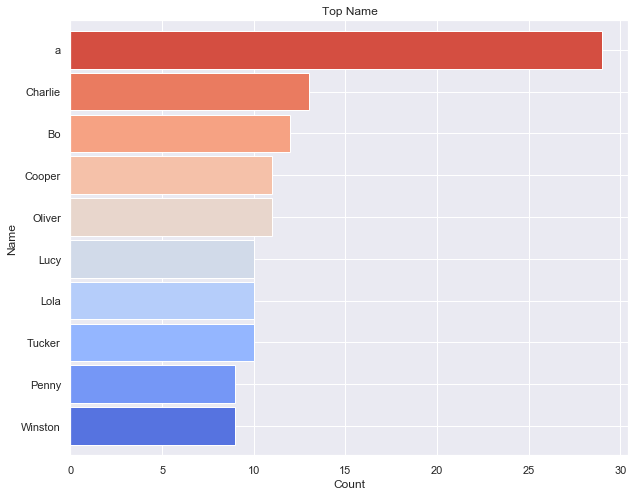

```python
twitter_archives.name.value_counts()[:10].sort_values(ascending=True).plot.barh(width=0.9,color=sns.color_palette('coolwarm',10))
plt.title('Top Name')
set_label('Count', 'Name')
```

Based on the above, it seems that 'a' is the most popular name, followed by Charlie. We can say that @WeRateDog might have use 'a' when they didnt know the dog's name.

### Do we have any relation betweet number of retweets and favorite count ?

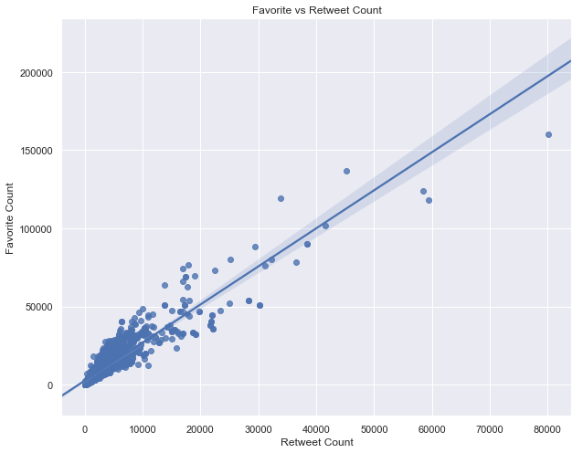

```python
sns.regplot(x='retweet_count',y='favorite_count', data=twitter_archives)
set_label("Retweet Count", "Favorite Count")
plt.title('Favorite vs Retweet Count');
```

### As @WeRateDogs got popularity ,did they reduce number of tweets per day?

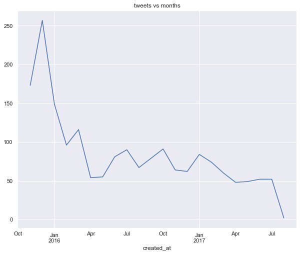

```python
twitter_archives['created_at'] = pd.to_datetime(twitter_archives.created_at)
twitter_archives.groupby(twitter_archives['created_at'].dt.to_period("M")).count()['id'].plot(title='tweets vs months')
```

We can see from the graph the number of tweets decreased as time goes.

## retweet count and the favorite count per month?

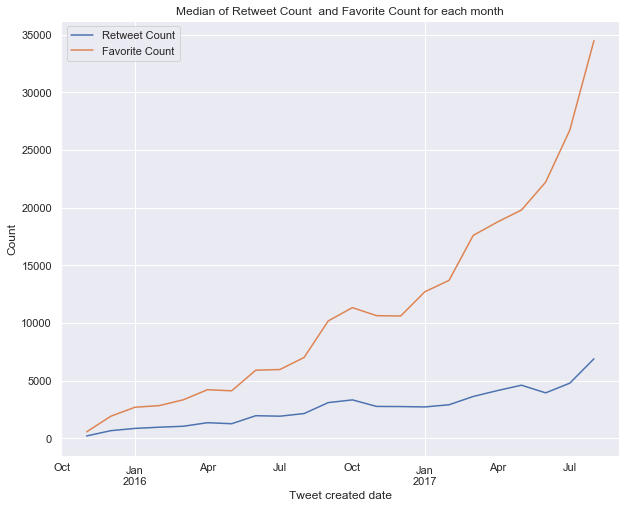

```python
twitter_archives.groupby(twitter_archives['created_at'].dt.to_period("M")).median()['retweet_count'].plot(label='Retweet Count')
twitter_archives.groupby(twitter_archives['created_at'].dt.to_period("M")).median()['favorite_count'].plot(label='Favorite Count')
plt.legend()
set_label('Tweet created date', 'Count')
plt.title('Median of Retweet Count  and Favorite Count for each month')
```